# Influence of personal and social benefits on the intention to donate blood in the context of age and the constructs of the Self-Determination Theory - Master Thesis

Tim Riester

2024-03-21

The following analyses are reported in our method study and sorted according to the order in which they appear in the corresponding report.

#Load data

```r
data  <- read.csv("data_project_1013280_2024_04_17_cut.csv", sep = ";")
```

##Of the total n = 405 participants, two people stated an age of under 18 or over 75. In addition, 7 participants did not pass the Attention Check. There were no overlaps between the participants.

#Clean data

```r
MA_data <- subset(data, ALTER >= 18 & ALTER <= 75 & ATTENTION_CHECK == 1)
```

#Overview

```r
describe(MA_data)
```

```
## MA_data
##
##  49  Variables      396  Observations
## --------------------------------------------------------------------------------
## c_0001
##        n  missing distinct     Info     Mean      Gmd
##      396        0        3    0.889    1.997    0.886
##
## Value          1     2     3
## Frequency    131   135   130
## Proportion 0.331 0.341 0.328
##
## For the frequency table, variable is rounded to the nearest 0
## --------------------------------------------------------------------------------
## ALTER
##        n  missing distinct     Info     Mean      Gmd      .05      .10
##      396        0       50    0.998    35.13    14.17     21.0     21.5
##      .25      .50      .75      .90      .95
##     24.0     32.0     45.0     54.0     58.0
##
## lowest : 18 19 20 21 22, highest: 64 65 66 68 74
## --------------------------------------------------------------------------------
## GESCHLECHT
##        n  missing distinct     Info     Mean      Gmd
##      396        0        3    0.597     1.28   0.4128
##
## Value          1     2     3
## Frequency    288   105     3
## Proportion 0.727 0.265 0.008
##
## For the frequency table, variable is rounded to the nearest 0
## --------------------------------------------------------------------------------
## BILDUNG
##        n  missing distinct     Info     Mean      Gmd
##      396        0        7    0.946    3.995    1.683
##
## Value          1     2     3     4     5     6     7
## Frequency      9    83    35   131    77    34    27
## Proportion 0.023 0.210 0.088 0.331 0.194 0.086 0.068
##
```

[output cut: 253 more lines]

```
## INTENTION_3
##        n  missing distinct     Info     Mean      Gmd
##      396        0        7    0.829    5.293    2.331
##
## Value          1     2     3     4     5     6     7
## Frequency     58    25    16    17    26    36   218
## Proportion 0.146 0.063 0.040 0.043 0.066 0.091 0.551
##
## For the frequency table, variable is rounded to the nearest 0
## --------------------------------------------------------------------------------
##
## Variables with all observations missing:
##
##  [1] X    X.1  X.2  X.3  X.4  X.5  X.6  X.7  X.8  X.9  X.10 X.11 X.12 X.13 X.14
## [16] X.15 X.16 X.17
```

#Data preperation

##Age Groups

```r
summary(MA_data$ALTER)
```

```
##    Min. 1st Qu.  Median    Mean 3rd Qu.    Max.
##   18.00   24.00   32.00   35.13   45.00   74.00
```

```r
MA_data$AGE_GROUP <- NA
MA_data$AGE_GROUP <- factor(
  MA_data$AGE_GROUP,
  levels = c(1,2),
  labels = c("18-29", "30-75")
)

MA_data$AGE_GROUP[which(MA_data$ALTER >= 18 & MA_data$ALTER <=29 )] <- "18-29"
MA_data$AGE_GROUP[which(MA_data$ALTER >= 30 & MA_data$ALTER <= 75 )] <- "30-75"


table(MA_data$ALTER<30, MA_data$ALTER>=30)
```

```
##
##         FALSE TRUE
##   FALSE     0  216
##   TRUE    180    0
```

```r
summary(MA_data$AGE_GROUP)
```

```
## 18-29 30-75
##   180   216
```

```r
agegroupwave <- c(
  "1" = "18-29",
  "2" = "30-75"
)

MA_data$AGE_GROUP_MEDIATION <- 0
MA_data$AGE_GROUP_MEDIATION[which(MA_data$ALTER >= 18 & MA_data$ALTER <= 29)] <- 1
MA_data$AGE_GROUP_MEDIATION[which(MA_data$ALTER >= 30 & MA_data$ALTER <= 75)] <- 2
MA_data$AGE_GROUP_MEDIATION <- as.integer(MA_data$AGE_GROUP_MEDIATION)
```

##Gender Groups

```r
MA_data$GENDER_GROUP <- NA
MA_data$GENDER_GROUP <- factor(
  MA_data$GENDER_GROUP,
  levels = c(1,2,3,4),
  labels = c("Weiblich","Männlich","Divers","Keine Angabe")
)

MA_data$GENDER_GROUP[which(MA_data$GESCHLECHT == 1)] <- "Weiblich"
MA_data$GENDER_GROUP[which(MA_data$GESCHLECHT == 2)] <- "Männlich"
MA_data$GENDER_GROUP[which(MA_data$GESCHLECHT == 3)] <- "Divers"
MA_data$GENDER_GROUP[which(MA_data$GESCHLECHT == 4)] <- "Keine Angabe"

summary(MA_data$GENDER_GROUP)
```

```
##     Weiblich     Männlich       Divers Keine Angabe
##          288          105            3            0
```

##Education Groups

```r
MA_data$EDUCATION_GROUP <- NA
MA_data$EDUCATION_GROUP <- factor(
MA_data$EDUCATION_GROUP,
levels = c(1,2,3,4,5,6,7),
labels = c("Hauptschulabschluss","Mittlere Reife","Fachhochschulreife","Allgemeine Hochschulreife","Bachelor","Master","Andere")
)

MA_data$EDUCATION_GROUP[which(MA_data$BILDUNG == 1)] <- "Hauptschulabschluss"
MA_data$EDUCATION_GROUP[which(MA_data$BILDUNG == 2)] <- "Mittlere Reife"
MA_data$EDUCATION_GROUP[which(MA_data$BILDUNG == 3)] <- "Fachhochschulreife"
MA_data$EDUCATION_GROUP[which(MA_data$BILDUNG == 4)] <- "Allgemeine Hochschulreife"
MA_data$EDUCATION_GROUP[which(MA_data$BILDUNG == 5)] <- "Bachelor"
MA_data$EDUCATION_GROUP[which(MA_data$BILDUNG == 6)] <- "Master"
MA_data$EDUCATION_GROUP[which(MA_data$BILDUNG == 7)] <- "Andere"

summary(MA_data$EDUCATION_GROUP)
```

```
##       Hauptschulabschluss            Mittlere Reife        Fachhochschulreife
##                         9                        83                        35
## Allgemeine Hochschulreife                  Bachelor                    Master
##                       131                        77                        34
##                    Andere
##                        27
```

##Country Groups

```r
MA_data$COUNTRY_GROUP <- NA
MA_data$COUNTRY_GROUP <- factor(
MA_data$COUNTRY_GROUP,
levels = c(1,2,3,4),
labels = c("Deutschland","Österreich","Schweiz","Andere")
)

MA_data$COUNTRY_GROUP[which(MA_data$LAND == 1)] <- "Deutschland"
MA_data$COUNTRY_GROUP[which(MA_data$LAND == 2)] <- "Österreich"
MA_data$COUNTRY_GROUP[which(MA_data$LAND == 3)] <- "Schweiz"
MA_data$COUNTRY_GROUP[which(MA_data$LAND == 4)] <- "Andere"

summary(MA_data$COUNTRY_GROUP)
```

```
## Deutschland  Österreich     Schweiz      Andere
##         392           1           2           1
```

##Blooddonation Behavior Group

```r
MA_data$BDB_GROUP <- NA
MA_data$BDB_GROUP <- factor(
MA_data$BDB_GROUP,
levels = c(1,2,3),
labels = c("Ja","Nein","Keine Angabe")
)

MA_data$BDB_GROUP[which(MA_data$BLUTSPENDEVERHALTEN == 1)] <- "Ja"
MA_data$BDB_GROUP[which(MA_data$BLUTSPENDEVERHALTEN == 2)] <- "Nein"
MA_data$BDB_GROUP[which(MA_data$BLUTSPENDEVERHALTEN == 3)] <- "Keine Angabe"

summary(MA_data$BDB_GROUP)
```

```
##           Ja         Nein Keine Angabe
##          303           93            0
```

##Blooddonor Organisation Groups

```r
MA_data$BDO_GROUP <- NA
MA_data$BDO_GROUP <- factor(
MA_data$BDO_GROUP,
levels = c(1,3,4),
labels = c("Deutsches Rotes Kreuz","Weiß ich nicht","Andere")
)

MA_data$BDO_GROUP[which(MA_data$BLUTSPENDEORGANISATION == 1)] <- "Deutsches Rotes Kreuz"
MA_data$BDO_GROUP[which(MA_data$BLUTSPENDEORGANISATION == 3)] <- "Weiß ich nicht"
MA_data$BDO_GROUP[which(MA_data$BLUTSPENDEORGANISATION == 4)] <- "Andere"

summary(MA_data$BDO_GROUP)
```

```
## Deutsches Rotes Kreuz        Weiß ich nicht                Andere
##                   250                    10                    43
##                  NA's
##                    93
```

##Experimental Conditions

```r
MA_data$Condition <- factor(MA_data$c_0001, levels = c(1,2,3))
labels = c("Individueller Anreiz", "Sozialer Anreiz", "Kontrollgruppe")

summary(data$c_0001)
```

```
##    Min. 1st Qu.  Median    Mean 3rd Qu.    Max.
##   1.000   1.000   2.000   1.998   3.000   3.000
```

#Descriptives

##Demographics

###The following table shows the distribution of survey participants by demographics and experimental condition (1 = Individual Benefit, 2 = Social Benefit, 3 = Control Group)

```r
##this code must be adapted according to the personal file path
MA_data <- apply_labels(MA_data,
AGE_GROUP = "Age group",
GENDER_GROUP = "Gender",
EDUCATION_GROUP = "Level of education",
COUNTRY_GROUP = "Residence country")

html_code <- MA_data %>%
tab_cells(AGE_GROUP,GENDER_GROUP,EDUCATION_GROUP) %>%
tab_cols(total(label = "Sum"),Condition) %>%
tab_stat_cases(total_label = "All") %>%
tab_pivot() %>%
htmlTable(align = "c",css.cell = c("width: 400px"))

file_path <- "C:\\Users\\timri\\Desktop\\Uni Vorlesungen\\Master GeKo\\Masterarbeit\\Statistiken und Auswertung\\Auswertung"
file_name <- "Deskriptiv.html"

writeLines(html_code, file.path("C:\\Users\\timri\\Desktop\\Uni Vorlesungen\\Master GeKo\\Masterarbeit\\Statistiken und Auswertung\\Auswertung", "Deskriptiv.html"))
```

```r
MA_data_table <- MA_data

label(MA_data_table$GENDER_GROUP)       <- "Geschlecht"
label(MA_data_table$ALTER)       <- "Alter"
label(MA_data_table$EDUCATION_GROUP)     <- "Bildung"
label(MA_data_table$COUNTRY_GROUP) <- "Land"
label(MA_data_table$BDB_GROUP) <- "Blutspendeverhalten"
label(MA_data_table$BDO_GROUP) <- "Blutspendeorganisation"

units(MA_data_table$ALTER)       <- "Jahre"

caption  <- "Deskriptive Daten"
#footnote <- "ᵃ Also known as Breslow thickness"

table1(~ GENDER_GROUP + ALTER + EDUCATION_GROUP + COUNTRY_GROUP + BDB_GROUP + BDO_GROUP | Condition, data=MA_data_table, overall=c(left="Total"), caption=caption)
```

Deskriptive Daten

|  | Total (N=396) | 1 (N=131) | 2 (N=135) | 3 (N=130) |
| --- | --- | --- | --- | --- |
| Geschlecht |  |  |  |  |
| Weiblich | 288 (72.7%) | 90 (68.7%) | 105 (77.8%) | 93 (71.5%) |
| Männlich | 105 (26.5%) | 41 (31.3%) | 28 (20.7%) | 36 (27.7%) |
| Divers | 3 (0.8%) | 0 (0%) | 2 (1.5%) | 1 (0.8%) |
| Keine Angabe | 0 (0%) | 0 (0%) | 0 (0%) | 0 (0%) |
| Alter (Jahre) |  |  |  |  |
| Mean (SD) | 35.1 (12.6) | 34.3 (11.7) | 36.0 (13.2) | 35.0 (13.0) |
| Median [Min, Max] | 32.0 [18.0, 74.0] | 31.0 [19.0, 68.0] | 34.0 [18.0, 74.0] | 32.0 [18.0, 66.0] |
| Bildung |  |  |  |  |
| Hauptschulabschluss | 9 (2.3%) | 2 (1.5%) | 3 (2.2%) | 4 (3.1%) |
| Mittlere Reife | 83 (21.0%) | 29 (22.1%) | 25 (18.5%) | 29 (22.3%) |
| Fachhochschulreife | 35 (8.8%) | 11 (8.4%) | 12 (8.9%) | 12 (9.2%) |
| Allgemeine Hochschulreife | 131 (33.1%) | 41 (31.3%) | 45 (33.3%) | 45 (34.6%) |
| Bachelor | 77 (19.4%) | 26 (19.8%) | 27 (20.0%) | 24 (18.5%) |
| Master | 34 (8.6%) | 14 (10.7%) | 11 (8.1%) | 9 (6.9%) |
| Andere | 27 (6.8%) | 8 (6.1%) | 12 (8.9%) | 7 (5.4%) |
| Land |  |  |  |  |
| Deutschland | 392 (99.0%) | 130 (99.2%) | 133 (98.5%) | 129 (99.2%) |
| Österreich | 1 (0.3%) | 0 (0%) | 1 (0.7%) | 0 (0%) |
| Schweiz | 2 (0.5%) | 1 (0.8%) | 0 (0%) | 1 (0.8%) |
| Andere | 1 (0.3%) | 0 (0%) | 1 (0.7%) | 0 (0%) |
| Blutspendeverhalten |  |  |  |  |
| Ja | 303 (76.5%) | 106 (80.9%) | 104 (77.0%) | 93 (71.5%) |
| Nein | 93 (23.5%) | 25 (19.1%) | 31 (23.0%) | 37 (28.5%) |
| Keine Angabe | 0 (0%) | 0 (0%) | 0 (0%) | 0 (0%) |
| Blutspendeorganisation |  |  |  |  |
| Deutsches Rotes Kreuz | 250 (63.1%) | 84 (64.1%) | 84 (62.2%) | 82 (63.1%) |
| Weiß ich nicht | 10 (2.5%) | 5 (3.8%) | 4 (3.0%) | 1 (0.8%) |
| Andere | 43 (10.9%) | 17 (13.0%) | 16 (11.9%) | 10 (7.7%) |
| Missing | 93 (23.5%) | 25 (19.1%) | 31 (23.0%) | 37 (28.5%) |

```r
table1(~ GENDER_GROUP + ALTER + EDUCATION_GROUP + COUNTRY_GROUP + BDB_GROUP + BDO_GROUP | AGE_GROUP, data=MA_data_table, overall=c(left="Total"), caption=caption)
```

Deskriptive Daten

|  | Total (N=396) | 18-29 (N=180) | 30-75 (N=216) |
| --- | --- | --- | --- |
| Geschlecht |  |  |  |
| Weiblich | 288 (72.7%) | 142 (78.9%) | 146 (67.6%) |
| Männlich | 105 (26.5%) | 36 (20.0%) | 69 (31.9%) |
| Divers | 3 (0.8%) | 2 (1.1%) | 1 (0.5%) |
| Keine Angabe | 0 (0%) | 0 (0%) | 0 (0%) |
| Alter (Jahre) |  |  |  |
| Mean (SD) | 35.1 (12.6) | 23.8 (2.67) | 44.6 (9.49) |
| Median [Min, Max] | 32.0 [18.0, 74.0] | 24.0 [18.0, 29.0] | 44.0 [30.0, 74.0] |
| Bildung |  |  |  |
| Hauptschulabschluss | 9 (2.3%) | 1 (0.6%) | 8 (3.7%) |
| Mittlere Reife | 83 (21.0%) | 9 (5.0%) | 74 (34.3%) |
| Fachhochschulreife | 35 (8.8%) | 7 (3.9%) | 28 (13.0%) |
| Allgemeine Hochschulreife | 131 (33.1%) | 89 (49.4%) | 42 (19.4%) |
| Bachelor | 77 (19.4%) | 53 (29.4%) | 24 (11.1%) |
| Master | 34 (8.6%) | 13 (7.2%) | 21 (9.7%) |
| Andere | 27 (6.8%) | 8 (4.4%) | 19 (8.8%) |
| Land |  |  |  |
| Deutschland | 392 (99.0%) | 177 (98.3%) | 215 (99.5%) |
| Österreich | 1 (0.3%) | 1 (0.6%) | 0 (0%) |
| Schweiz | 2 (0.5%) | 2 (1.1%) | 0 (0%) |
| Andere | 1 (0.3%) | 0 (0%) | 1 (0.5%) |
| Blutspendeverhalten |  |  |  |
| Ja | 303 (76.5%) | 97 (53.9%) | 206 (95.4%) |
| Nein | 93 (23.5%) | 83 (46.1%) | 10 (4.6%) |
| Keine Angabe | 0 (0%) | 0 (0%) | 0 (0%) |
| Blutspendeorganisation |  |  |  |
| Deutsches Rotes Kreuz | 250 (63.1%) | 59 (32.8%) | 191 (88.4%) |
| Weiß ich nicht | 10 (2.5%) | 5 (2.8%) | 5 (2.3%) |
| Andere | 43 (10.9%) | 33 (18.3%) | 10 (4.6%) |
| Missing | 93 (23.5%) | 83 (46.1%) | 10 (4.6%) |

```r
#footnote=footnote)
```

##Overall percentages for gender and education are shown such as descriptive data for age by condition.

```r
N <- nrow(MA_data)
ageRange_min <- min(MA_data$ALTER)
ageRange_max <- max(MA_data$ALTER)
ageMean <- mean(MA_data$ALTER)
ageSD <- sd(MA_data$ALTER)
ageMedian <- median(MA_data$ALTER)
table(MA_data$ALTER)
```

```
##
## 18 19 20 21 22 23 24 25 26 27 28 29 30 31 32 33 34 35 36 37 38 39 40 41 42 43
##  3  3 10 24 30 13 21 31 17  7 11 10  6  7  8  7 12  8  2 12  6  8  6  7  4 12
## 44 45 46 47 48 49 50 51 52 53 54 55 56 57 58 59 60 61 62 64 65 66 68 74
## 10  7  9  5 10  8  2  7  2  4 10  5  4  6  7  2  2  2  2  1  1  2  2  1
```

```r
round(table(MA_data$GESCHLECHT)/N*100,2)
```

```
##
##     1     2     3
## 72.73 26.52  0.76
```

```r
round(table(MA_data$BILDUNG)/N*100,2)
```

```
##
##     1     2     3     4     5     6     7
##  2.27 20.96  8.84 33.08 19.44  8.59  6.82
```

```r
describeBy(MA_data$ALTER,MA_data$Condition)
```

```
##
##  Descriptive statistics by group
## group: 1
##    vars   n  mean    sd median trimmed   mad min max range skew kurtosis   se
## X1    1 131 34.31 11.73     31   33.22 11.86  19  68    49 0.67    -0.54 1.02
## ------------------------------------------------------------
## group: 2
##    vars   n  mean    sd median trimmed   mad min max range skew kurtosis   se
## X1    1 135 36.04 13.17     34   34.97 14.83  18  74    56 0.58    -0.72 1.13
## ------------------------------------------------------------
## group: 3
##    vars   n  mean sd median trimmed   mad min max range skew kurtosis   se
## X1    1 130 35.02 13     32   33.85 14.83  18  66    48 0.61     -0.9 1.14
```

```r
table1(~ ageRange_max + ageRange_min + ageMean + ageSD + ageMedian, data=MA_data_table, caption=caption)
```

Deskriptive Daten

|  | Overall (N=1) |
| --- | --- |
| ageRange_max |  |
| Mean (SD) | 74.0 (NA) |
| Median [Min, Max] | 74.0 [74.0, 74.0] |
| ageRange_min |  |
| Mean (SD) | 18.0 (NA) |
| Median [Min, Max] | 18.0 [18.0, 18.0] |
| ageMean |  |
| Mean (SD) | 35.1 (NA) |
| Median [Min, Max] | 35.1 [35.1, 35.1] |
| ageSD |  |
| Mean (SD) | 12.6 (NA) |
| Median [Min, Max] | 12.6 [12.6, 12.6] |
| ageMedian |  |
| Mean (SD) | 32.0 (NA) |
| Median [Min, Max] | 32.0 [32.0, 32.0] |

##Graphical representation of the age distribution

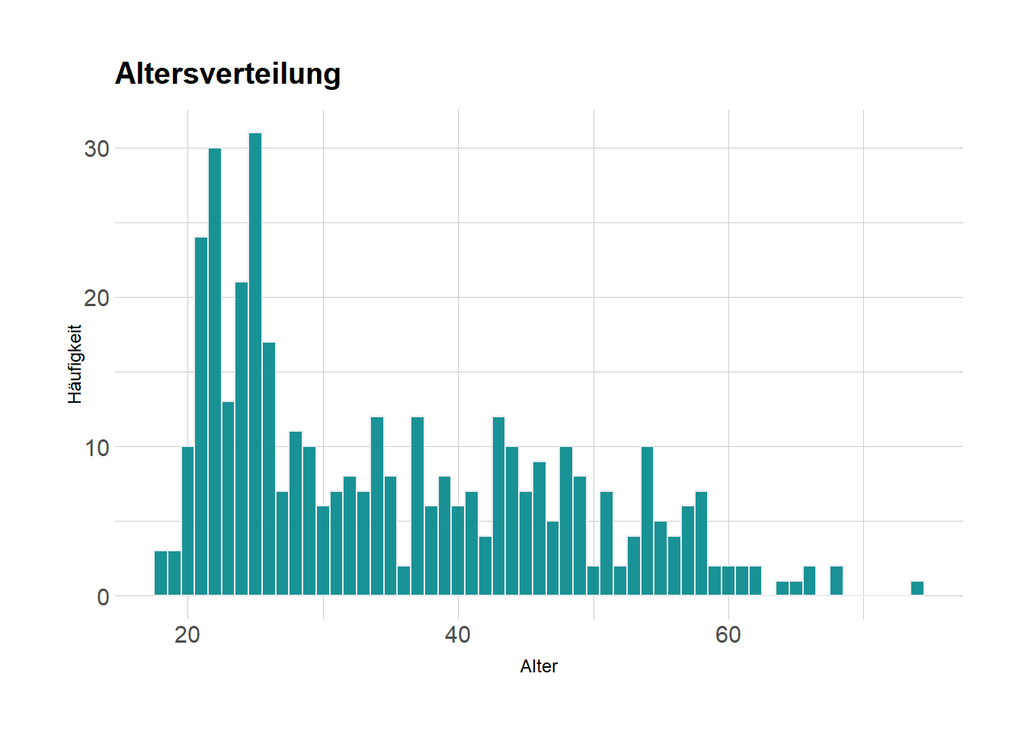

```r
p <- MA_data %>%
  filter( ALTER<75 ) %>%
  ggplot( aes(x=ALTER)) +
    geom_histogram( binwidth=1, fill="#00868B", color="#e9ecef", alpha=0.9) +
    ggtitle("Altersverteilung") +
    theme_ipsum() +
    theme(
      plot.title = element_text(size=15),
      axis.title.x = element_text(hjust = 0.5, vjust = -0.5),
      axis.title.y = element_text(hjust = 0.5, vjust = -0.5)
    ) +
  labs(
    x = "Alter",
    y = "Häufigkeit"
  )
p
```

```r
shapiro.test(MA_data$ALTER)
```

```
##
##  Shapiro-Wilk normality test
##
## data:  MA_data$ALTER
## W = 0.91663, p-value = 5.395e-14
```

##Determinants Self-Determination Theory ###Creat Index

```r
#AMOTIVATION
MA_data$AMOTIVATION_SUM <- (MA_data$AMOTIVATION_1 + MA_data$AMOTIVATION_2 + MA_data$AMOTIVATION_3) / 3

psych::alpha(subset(MA_data, select = c(AMOTIVATION_1,AMOTIVATION_2,AMOTIVATION_3)))
```

```
##
## Reliability analysis
## Call: psych::alpha(x = subset(MA_data, select = c(AMOTIVATION_1, AMOTIVATION_2,
##     AMOTIVATION_3)))
##
##   raw_alpha std.alpha G6(smc) average_r S/N   ase mean  sd median_r
##       0.53      0.56    0.49       0.3 1.3 0.042  2.6 1.3     0.25
##
##     95% confidence boundaries
##          lower alpha upper
## Feldt     0.44  0.53  0.60
## Duhachek  0.44  0.53  0.61
##
##  Reliability if an item is dropped:
##               raw_alpha std.alpha G6(smc) average_r  S/N alpha se var.r med.r
## AMOTIVATION_1      0.29      0.29    0.17      0.17 0.42    0.070    NA  0.17
## AMOTIVATION_2      0.38      0.40    0.25      0.25 0.67    0.058    NA  0.25
## AMOTIVATION_3      0.64      0.65    0.48      0.48 1.83    0.035    NA  0.48
##
##  Item statistics
##                 n raw.r std.r r.cor r.drop mean  sd
## AMOTIVATION_1 396  0.73  0.79  0.64   0.46  1.8 1.4
## AMOTIVATION_2 396  0.73  0.75  0.57   0.37  3.3 1.8
## AMOTIVATION_3 396  0.72  0.65  0.32   0.24  2.7 2.2
##
## Non missing response frequency for each item
##                  1    2    3    4    5    6    7 miss
## AMOTIVATION_1 0.68 0.13 0.07 0.04 0.05 0.03 0.01    0
## AMOTIVATION_2 0.21 0.16 0.19 0.18 0.11 0.09 0.06    0
## AMOTIVATION_3 0.50 0.13 0.07 0.06 0.07 0.04 0.12    0
```

```r
#Cronbachs α : .53

psych::alpha(subset(MA_data, select = c(AMOTIVATION_1,AMOTIVATION_2)))
```

```
##
## Reliability analysis
## Call: psych::alpha(x = subset(MA_data, select = c(AMOTIVATION_1, AMOTIVATION_2)))
##
##   raw_alpha std.alpha G6(smc) average_r S/N   ase mean  sd median_r
##       0.64      0.65    0.48      0.48 1.8 0.035  2.6 1.4     0.48
##
##     95% confidence boundaries
##          lower alpha upper
## Feldt     0.56  0.64  0.70
## Duhachek  0.57  0.64  0.71
##
##  Reliability if an item is dropped:
##               raw_alpha std.alpha G6(smc) average_r  S/N alpha se var.r med.r
## AMOTIVATION_1      0.38      0.48    0.23      0.48 0.91       NA     0  0.48
## AMOTIVATION_2      0.59      0.48    0.23      0.48 0.91       NA     0  0.48
##
##  Item statistics
##                 n raw.r std.r r.cor r.drop mean  sd
## AMOTIVATION_1 396  0.82  0.86  0.59   0.48  1.8 1.4
## AMOTIVATION_2 396  0.89  0.86  0.59   0.48  3.3 1.8
##
## Non missing response frequency for each item
##                  1    2    3    4    5    6    7 miss
## AMOTIVATION_1 0.68 0.13 0.07 0.04 0.05 0.03 0.01    0
## AMOTIVATION_2 0.21 0.16 0.19 0.18 0.11 0.09 0.06    0
```

```r
#Cronbachs α : .64

MA_data$AMOTIVATION_SUM_1_2 <- (MA_data$AMOTIVATION_1 + MA_data$AMOTIVATION_2) / 2

psych::alpha(subset(MA_data, select = c(AMOTIVATION_1,AMOTIVATION_3)))
```

```
##
## Reliability analysis
## Call: psych::alpha(x = subset(MA_data, select = c(AMOTIVATION_1, AMOTIVATION_3)))
##
##   raw_alpha std.alpha G6(smc) average_r  S/N   ase mean  sd median_r
##       0.38       0.4    0.25      0.25 0.67 0.058  2.2 1.4     0.25
##
##     95% confidence boundaries
##          lower alpha upper
## Feldt     0.24  0.38  0.49
## Duhachek  0.26  0.38  0.49
##
##  Reliability if an item is dropped:
##               raw_alpha std.alpha G6(smc) average_r  S/N alpha se var.r med.r
## AMOTIVATION_1      0.17      0.25   0.063      0.25 0.33       NA     0  0.25
## AMOTIVATION_3      0.37      0.25   0.063      0.25 0.33       NA     0  0.25
##
##  Item statistics
##                 n raw.r std.r r.cor r.drop mean  sd
## AMOTIVATION_1 396  0.69  0.79   0.4   0.25  1.8 1.4
## AMOTIVATION_3 396  0.87  0.79   0.4   0.25  2.7 2.2
##
## Non missing response frequency for each item
##                  1    2    3    4    5    6    7 miss
## AMOTIVATION_1 0.68 0.13 0.07 0.04 0.05 0.03 0.01    0
## AMOTIVATION_3 0.50 0.13 0.07 0.06 0.07 0.04 0.12    0
```

```r
psych::alpha(subset(MA_data, select = c(AMOTIVATION_2,AMOTIVATION_3)))
```

```
##
## Reliability analysis
## Call: psych::alpha(x = subset(MA_data, select = c(AMOTIVATION_2, AMOTIVATION_3)))
##
##   raw_alpha std.alpha G6(smc) average_r  S/N  ase mean  sd median_r
##       0.29      0.29    0.17      0.17 0.42 0.07    3 1.5     0.17
##
##     95% confidence boundaries
##          lower alpha upper
## Feldt     0.14  0.29  0.42
## Duhachek  0.15  0.29  0.43
##
##  Reliability if an item is dropped:
##               raw_alpha std.alpha G6(smc) average_r  S/N alpha se var.r med.r
## AMOTIVATION_2      0.14      0.17    0.03      0.17 0.21       NA     0  0.17
## AMOTIVATION_3      0.21      0.17    0.03      0.17 0.21       NA     0  0.17
##
##  Item statistics
##                 n raw.r std.r r.cor r.drop mean  sd
## AMOTIVATION_2 396  0.71  0.77  0.32   0.17  3.3 1.8
## AMOTIVATION_3 396  0.81  0.77  0.32   0.17  2.7 2.2
##
## Non missing response frequency for each item
##                  1    2    3    4    5    6    7 miss
## AMOTIVATION_2 0.21 0.16 0.19 0.18 0.11 0.09 0.06    0
## AMOTIVATION_3 0.50 0.13 0.07 0.06 0.07 0.04 0.12    0
```

```r
#EXTERNAL_REGULATION
MA_data$EXTERNAL_REGULATION_SUM <- (MA_data$EXTERNAL_REGULATION_1 + MA_data$EXTERNAL_REGULATION_2 + MA_data$EXTERNAL_REGULATION_3) / 3

psych::alpha(subset(MA_data, select = c(EXTERNAL_REGULATION_1,EXTERNAL_REGULATION_2,EXTERNAL_REGULATION_2)))
```

```
## In smc, smcs < 0 were set to .0
## In smc, smcs < 0 were set to .0
## In smc, smcs < 0 were set to .0
```

```
##
## Reliability analysis
## Call: psych::alpha(x = subset(MA_data, select = c(EXTERNAL_REGULATION_1,
##     EXTERNAL_REGULATION_2, EXTERNAL_REGULATION_2)))
##
##   raw_alpha std.alpha G6(smc) average_r S/N   ase mean  sd median_r
##       0.85      0.84    0.59      0.64 5.2 0.015  2.1 1.4     0.45
##
##     95% confidence boundaries
##          lower alpha upper
## Feldt     0.82  0.85  0.87
## Duhachek  0.82  0.85  0.87
##
##  Reliability if an item is dropped:
##                         raw_alpha std.alpha G6(smc) average_r S/N alpha se
## EXTERNAL_REGULATION_1        1.00      1.00    0.50      1.00 Inf    0.000
## EXTERNAL_REGULATION_2        0.62      0.62    0.45      0.45 1.7    0.038
## EXTERNAL_REGULATION_2.1      0.62      0.62    0.45      0.45 1.7    0.038
##                         var.r med.r
## EXTERNAL_REGULATION_1      NA  1.00
## EXTERNAL_REGULATION_2      NA  0.45
## EXTERNAL_REGULATION_2.1    NA  0.45
##
##  Item statistics
##                           n raw.r std.r r.cor r.drop mean  sd
## EXTERNAL_REGULATION_1   396  0.71  0.73  0.55   0.45  1.9 1.5
## EXTERNAL_REGULATION_2   396  0.95  0.94  0.72   0.87  2.2 1.7
## EXTERNAL_REGULATION_2.1 396  0.95  0.94  0.72   0.87  2.2 1.7
##
## Non missing response frequency for each item
##                            1    2    3    4    5    6    7 miss
## EXTERNAL_REGULATION_1   0.63 0.14 0.07 0.06 0.06 0.03 0.02    0
## EXTERNAL_REGULATION_2   0.54 0.15 0.07 0.10 0.08 0.03 0.03    0
## EXTERNAL_REGULATION_2.1 0.54 0.15 0.07 0.10 0.08 0.03 0.03    0
```

```r
#Cronbachs α : .85

#INTROJECTED_REGULATION
MA_data$INTROJECTED_REGULATION_SUM <- (MA_data$INTROJECTED_REGULATION_1 + MA_data$INTROJECTED_REGULATION_2 + MA_data$INTROJECTED_REGULATION_3) / 3

psych::alpha(subset(MA_data, select = c(INTROJECTED_REGULATION_1,INTROJECTED_REGULATION_2,INTROJECTED_REGULATION_3)))
```

```
##
## Reliability analysis
## Call: psych::alpha(x = subset(MA_data, select = c(INTROJECTED_REGULATION_1,
##     INTROJECTED_REGULATION_2, INTROJECTED_REGULATION_3)))
##
##   raw_alpha std.alpha G6(smc) average_r S/N   ase mean  sd median_r
##        0.8       0.8    0.73      0.57   4 0.017    4 1.6     0.57
##
##     95% confidence boundaries
##          lower alpha upper
## Feldt     0.76   0.8  0.83
## Duhachek  0.77   0.8  0.83
##
##  Reliability if an item is dropped:
##                          raw_alpha std.alpha G6(smc) average_r S/N alpha se
## INTROJECTED_REGULATION_1      0.72      0.72    0.57      0.57 2.6    0.028
## INTROJECTED_REGULATION_2      0.71      0.71    0.55      0.55 2.5    0.029
## INTROJECTED_REGULATION_3      0.75      0.75    0.60      0.60 2.9    0.025
##                          var.r med.r
## INTROJECTED_REGULATION_1    NA  0.57
## INTROJECTED_REGULATION_2    NA  0.55
## INTROJECTED_REGULATION_3    NA  0.60
##
##  Item statistics
##                            n raw.r std.r r.cor r.drop mean  sd
## INTROJECTED_REGULATION_1 396  0.85  0.85  0.73   0.65  3.3 1.9
## INTROJECTED_REGULATION_2 396  0.85  0.85  0.74   0.66  4.1 1.9
## INTROJECTED_REGULATION_3 396  0.84  0.84  0.70   0.63  4.5 2.0
##
## Non missing response frequency for each item
##                             1    2    3    4    5    6    7 miss
## INTROJECTED_REGULATION_1 0.25 0.15 0.13 0.18 0.14 0.06 0.09    0
## INTROJECTED_REGULATION_2 0.14 0.12 0.09 0.18 0.22 0.13 0.12    0
## INTROJECTED_REGULATION_3 0.12 0.07 0.11 0.19 0.16 0.15 0.20    0
```

```r
#Cronbachs α : .80

#IDENTIFIED_REGUALTION
MA_data$IDENTIFIED_REGUALTION_SUM <- (MA_data$IDENTIFIED_REGUALTION_1 + MA_data$IDENTIFIED_REGUALTION_2 + MA_data$IDENTIFIED_REGUALTION_3) / 3

psych::alpha(subset(MA_data, select = c(IDENTIFIED_REGUALTION_1,IDENTIFIED_REGUALTION_2,IDENTIFIED_REGUALTION_3)))
```

```
##
## Reliability analysis
## Call: psych::alpha(x = subset(MA_data, select = c(IDENTIFIED_REGUALTION_1,
##     IDENTIFIED_REGUALTION_2, IDENTIFIED_REGUALTION_3)))
##
##   raw_alpha std.alpha G6(smc) average_r S/N   ase mean  sd median_r
##       0.52      0.61    0.53      0.35 1.6 0.038  6.3 0.8     0.32
##
##     95% confidence boundaries
##          lower alpha upper
## Feldt     0.43  0.52  0.60
## Duhachek  0.44  0.52  0.59
##
##  Reliability if an item is dropped:
##                         raw_alpha std.alpha G6(smc) average_r  S/N alpha se
## IDENTIFIED_REGUALTION_1      0.65      0.65    0.48      0.48 1.85    0.035
## IDENTIFIED_REGUALTION_2      0.41      0.48    0.32      0.32 0.92    0.047
## IDENTIFIED_REGUALTION_3      0.32      0.39    0.25      0.25 0.65    0.052
##                         var.r med.r
## IDENTIFIED_REGUALTION_1    NA  0.48
## IDENTIFIED_REGUALTION_2    NA  0.32
## IDENTIFIED_REGUALTION_3    NA  0.25
##
##  Item statistics
##                           n raw.r std.r r.cor r.drop mean   sd
## IDENTIFIED_REGUALTION_1 396  0.85  0.69  0.41   0.33  5.6 1.60
## IDENTIFIED_REGUALTION_2 396  0.64  0.77  0.59   0.39  6.7 0.75
## IDENTIFIED_REGUALTION_3 396  0.70  0.80  0.65   0.45  6.6 0.82
##
## Non missing response frequency for each item
##                            1    2    3    4    5    6    7 miss
## IDENTIFIED_REGUALTION_1 0.04 0.02 0.06 0.10 0.19 0.19 0.40    0
## IDENTIFIED_REGUALTION_2 0.00 0.00 0.00 0.01 0.07 0.14 0.78    0
## IDENTIFIED_REGUALTION_3 0.00 0.00 0.01 0.01 0.05 0.18 0.74    0
```

```r
#Cronbachs α : .52

MA_data$IDENTIFIED_REGUALTION_SUM_2_3 <- (MA_data$IDENTIFIED_REGUALTION_2 + MA_data$IDENTIFIED_REGUALTION_3) / 2

psych::alpha(subset(MA_data, select = c(IDENTIFIED_REGUALTION_2,IDENTIFIED_REGUALTION_3)))
```

```
##
## Reliability analysis
## Call: psych::alpha(x = subset(MA_data, select = c(IDENTIFIED_REGUALTION_2,
##     IDENTIFIED_REGUALTION_3)))
##
##   raw_alpha std.alpha G6(smc) average_r S/N   ase mean   sd median_r
##       0.65      0.65    0.48      0.48 1.8 0.035  6.6 0.67     0.48
##
##     95% confidence boundaries
##          lower alpha upper
## Feldt     0.57  0.65  0.71
## Duhachek  0.58  0.65  0.72
##
##  Reliability if an item is dropped:
##                         raw_alpha std.alpha G6(smc) average_r  S/N alpha se
## IDENTIFIED_REGUALTION_2      0.44      0.48    0.23      0.48 0.92       NA
## IDENTIFIED_REGUALTION_3      0.53      0.48    0.23      0.48 0.92       NA
##                         var.r med.r
## IDENTIFIED_REGUALTION_2     0  0.48
## IDENTIFIED_REGUALTION_3     0  0.48
##
##  Item statistics
##                           n raw.r std.r r.cor r.drop mean   sd
## IDENTIFIED_REGUALTION_2 396  0.85  0.86   0.6   0.48  6.7 0.75
## IDENTIFIED_REGUALTION_3 396  0.87  0.86   0.6   0.48  6.6 0.82
##
## Non missing response frequency for each item
##                         1 2    3    4    5    6    7 miss
## IDENTIFIED_REGUALTION_2 0 0 0.00 0.01 0.07 0.14 0.78    0
## IDENTIFIED_REGUALTION_3 0 0 0.01 0.01 0.05 0.18 0.74    0
```

```r
#Cronbachs α : .65

#INTEGRATED_REGULATION
MA_data$INTEGRATED_REGULATION_SUM <- (MA_data$INTEGRATED_REGULATION_1 + MA_data$INTEGRATED_REGULATION_2 + MA_data$INTEGRATED_REGULATION_3) / 3

psych::alpha(subset(MA_data, select = c(INTEGRATED_REGULATION_1,INTEGRATED_REGULATION_2,INTEGRATED_REGULATION_3)))
```

```
##
## Reliability analysis
## Call: psych::alpha(x = subset(MA_data, select = c(INTEGRATED_REGULATION_1,
##     INTEGRATED_REGULATION_2, INTEGRATED_REGULATION_3)))
##
##   raw_alpha std.alpha G6(smc) average_r S/N   ase mean  sd median_r
##       0.81      0.81    0.74      0.58 4.2 0.017  4.9 1.5     0.55
##
##     95% confidence boundaries
##          lower alpha upper
## Feldt     0.77  0.81  0.84
## Duhachek  0.77  0.81  0.84
##
##  Reliability if an item is dropped:
##                         raw_alpha std.alpha G6(smc) average_r S/N alpha se
## INTEGRATED_REGULATION_1      0.71      0.71    0.55      0.55 2.4    0.029
## INTEGRATED_REGULATION_2      0.80      0.80    0.67      0.67 4.1    0.020
## INTEGRATED_REGULATION_3      0.69      0.69    0.52      0.52 2.2    0.032
##                         var.r med.r
## INTEGRATED_REGULATION_1    NA  0.55
## INTEGRATED_REGULATION_2    NA  0.67
## INTEGRATED_REGULATION_3    NA  0.52
##
##  Item statistics
##                           n raw.r std.r r.cor r.drop mean  sd
## INTEGRATED_REGULATION_1 396  0.86  0.86  0.76   0.68  4.7 1.8
## INTEGRATED_REGULATION_2 396  0.82  0.81  0.65   0.59  4.8 1.8
## INTEGRATED_REGULATION_3 396  0.87  0.87  0.79   0.70  5.1 1.8
##
## Non missing response frequency for each item
##                            1    2    3    4    5    6    7 miss
## INTEGRATED_REGULATION_1 0.07 0.09 0.09 0.16 0.20 0.17 0.22    0
## INTEGRATED_REGULATION_2 0.08 0.08 0.05 0.19 0.19 0.20 0.21    0
## INTEGRATED_REGULATION_3 0.04 0.07 0.07 0.18 0.18 0.17 0.29    0
```

```r
#Cronbachs α : .81

#INTRINSIC_REGUALTION
MA_data$INTRINSIC_REGULATION_SUM <- (MA_data$INTRINSIC_REGUALTION_1 + MA_data$INTRINSIC_REGUALTION_2 + MA_data$INTRINSIC_REGUALTION_3) / 3

psych::alpha(subset(MA_data, select = c(INTRINSIC_REGUALTION_1,INTRINSIC_REGUALTION_2,INTRINSIC_REGUALTION_3)))
```

```
##
## Reliability analysis
## Call: psych::alpha(x = subset(MA_data, select = c(INTRINSIC_REGUALTION_1,
##     INTRINSIC_REGUALTION_2, INTRINSIC_REGUALTION_3)))
##
##   raw_alpha std.alpha G6(smc) average_r S/N  ase mean  sd median_r
##       0.77      0.77    0.71      0.53 3.4 0.02  4.5 1.7     0.49
##
##     95% confidence boundaries
##          lower alpha upper
## Feldt     0.73  0.77  0.81
## Duhachek  0.74  0.77  0.81
##
##  Reliability if an item is dropped:
##                        raw_alpha std.alpha G6(smc) average_r S/N alpha se var.r
## INTRINSIC_REGUALTION_1      0.66      0.66    0.49      0.49 2.0    0.034    NA
## INTRINSIC_REGUALTION_2      0.78      0.78    0.65      0.65 3.6    0.022    NA
## INTRINSIC_REGUALTION_3      0.63      0.63    0.46      0.46 1.7    0.038    NA
##                        med.r
## INTRINSIC_REGUALTION_1  0.49
## INTRINSIC_REGUALTION_2  0.65
## INTRINSIC_REGUALTION_3  0.46
##
##  Item statistics
##                          n raw.r std.r r.cor r.drop mean  sd
## INTRINSIC_REGUALTION_1 396  0.85  0.84  0.74   0.64  4.9 2.0
## INTRINSIC_REGUALTION_2 396  0.77  0.78  0.59   0.52  4.9 1.9
## INTRINSIC_REGUALTION_3 396  0.87  0.86  0.77   0.67  3.7 2.1
##
## Non missing response frequency for each item
##                           1    2    3    4    5    6    7 miss
## INTRINSIC_REGUALTION_1 0.11 0.07 0.06 0.13 0.13 0.18 0.32    0
## INTRINSIC_REGUALTION_2 0.09 0.07 0.06 0.16 0.18 0.16 0.29    0
## INTRINSIC_REGUALTION_3 0.24 0.12 0.11 0.15 0.12 0.11 0.15    0
```

```r
#Cronbachs α : .77
```

###Creat Index Intention

```r
MA_data$INTENTION_SUM <- (MA_data$INTENTION_1 + MA_data$INTENTION_2 + MA_data$INTENTION_3) / 3

psych::alpha(subset(MA_data, select = c(INTENTION_1,INTENTION_2,INTENTION_3)))
```

```
##
## Reliability analysis
## Call: psych::alpha(x = subset(MA_data, select = c(INTENTION_1, INTENTION_2,
##     INTENTION_3)))
##
##   raw_alpha std.alpha G6(smc) average_r S/N    ase mean  sd median_r
##       0.98      0.98    0.97      0.93  40 0.0022  5.3 2.2     0.92
##
##     95% confidence boundaries
##          lower alpha upper
## Feldt     0.97  0.98  0.98
## Duhachek  0.97  0.98  0.98
##
##  Reliability if an item is dropped:
##             raw_alpha std.alpha G6(smc) average_r S/N alpha se var.r med.r
## INTENTION_1      0.96      0.96    0.92      0.92  24   0.0041    NA  0.92
## INTENTION_2      0.98      0.98    0.96      0.96  48   0.0020    NA  0.96
## INTENTION_3      0.95      0.95    0.91      0.91  19   0.0050    NA  0.91
##
##  Item statistics
##               n raw.r std.r r.cor r.drop mean  sd
## INTENTION_1 396  0.98  0.98  0.97   0.95  5.2 2.3
## INTENTION_2 396  0.96  0.97  0.93   0.92  5.5 2.2
## INTENTION_3 396  0.98  0.98  0.98   0.97  5.3 2.3
##
## Non missing response frequency for each item
##                1    2    3    4    5    6    7 miss
## INTENTION_1 0.15 0.07 0.05 0.05 0.07 0.08 0.53    0
## INTENTION_2 0.12 0.05 0.03 0.05 0.08 0.09 0.58    0
## INTENTION_3 0.15 0.06 0.04 0.04 0.07 0.09 0.55    0
```

```r
#Cronbachs α : 0.98
```

#Analysis of the preconditions

##Test for the prerequisite of a two-factorial ANOVA

###Identify and select outliers

```r
identify_outliers <- function(data) {
  Q1 <- quantile(data$INTENTION_SUM, 0.25)
  Q3 <- quantile(data$INTENTION_SUM, 0.75)
  IQR <- Q3 - Q1

  lower_bound <- Q1 - 1.5 * IQR
  upper_bound <- Q3 + 1.5 * IQR

  outliers <- data %>%
    filter(INTENTION_SUM < lower_bound | INTENTION_SUM > upper_bound)

  return(outliers)
}


outliers <- identify_outliers(MA_data)


print(outliers)
```

```
##  [1] c_0001                        ALTER
##  [3] GESCHLECHT                    BILDUNG
##  [5] LAND                          LAND_2
##  [7] BLUTSPENDEVERHALTEN           BLUTSPENDEORGANISATION
##  [9] BLUTSPENDEORGANISATION_2      AMOTIVATION_1
## [11] AMOTIVATION_2                 AMOTIVATION_3
## [13] EXTERNAL_REGULATION_1         EXTERNAL_REGULATION_2
## [15] EXTERNAL_REGULATION_3         INTROJECTED_REGULATION_1
## [17] INTROJECTED_REGULATION_2      ATTENTION_CHECK
## [19] INTROJECTED_REGULATION_3      IDENTIFIED_REGUALTION_1
## [21] IDENTIFIED_REGUALTION_2       IDENTIFIED_REGUALTION_3
## [23] INTEGRATED_REGULATION_1       INTEGRATED_REGULATION_2
## [25] INTEGRATED_REGULATION_3       INTRINSIC_REGUALTION_1
## [27] INTRINSIC_REGUALTION_2        INTRINSIC_REGUALTION_3
## [29] INTENTION_1                   INTENTION_2
```

[output cut: 19 more lines]

```r
MA_data_no_outliers <- MA_data %>%
  filter(!(INTENTION_SUM %in% outliers$INTENTION_SUM))


summary(MA_data_no_outliers)
```

```
##      c_0001          ALTER         GESCHLECHT      BILDUNG           LAND
##  Min.   :1.000   Min.   :18.00   Min.   :1.00   Min.   :1.000   Min.   :1.00
##  1st Qu.:1.000   1st Qu.:24.00   1st Qu.:1.00   1st Qu.:3.000   1st Qu.:1.00
##  Median :2.000   Median :32.00   Median :1.00   Median :4.000   Median :1.00
##  Mean   :1.997   Mean   :35.13   Mean   :1.28   Mean   :3.995   Mean   :1.02
##  3rd Qu.:3.000   3rd Qu.:45.00   3rd Qu.:2.00   3rd Qu.:5.000   3rd Qu.:1.00
##  Max.   :3.000   Max.   :74.00   Max.   :3.00   Max.   :7.000   Max.   :4.00
##
##     LAND_2          BLUTSPENDEVERHALTEN BLUTSPENDEORGANISATION
##  Length:396         Min.   :1.000       Min.   :-77.00
##  Class :character   1st Qu.:1.000       1st Qu.:  1.00
##  Mode  :character   Median :1.000       Median :  1.00
##                     Mean   :1.235       Mean   :-16.94
##                     3rd Qu.:1.000       3rd Qu.:  1.00
##                     Max.   :2.000       Max.   :  4.00
##
##  BLUTSPENDEORGANISATION_2 AMOTIVATION_1   AMOTIVATION_2   AMOTIVATION_3
##  Length:396               Min.   :1.000   Min.   :1.000   Min.   :1.000
##  Class :character         1st Qu.:1.000   1st Qu.:2.000   1st Qu.:1.000
##  Mode  :character         Median :1.000   Median :3.000   Median :1.000
##                           Mean   :1.798   Mean   :3.323   Mean   :2.669
##                           3rd Qu.:2.000   3rd Qu.:5.000   3rd Qu.:4.000
##                           Max.   :7.000   Max.   :7.000   Max.   :7.000
##
##  EXTERNAL_REGULATION_1 EXTERNAL_REGULATION_2 EXTERNAL_REGULATION_3
##  Min.   :1.000         Min.   :1.000         Min.   :1.000
##  1st Qu.:1.000         1st Qu.:1.000         1st Qu.:1.000
##  Median :1.000         Median :1.000         Median :1.000
##  Mean   :1.917         Mean   :2.227         Mean   :1.876
##  3rd Qu.:2.000         3rd Qu.:3.000         3rd Qu.:2.000
##  Max.   :7.000         Max.   :7.000         Max.   :7.000
##
##  INTROJECTED_REGULATION_1 INTROJECTED_REGULATION_2 ATTENTION_CHECK
##  Min.   :1.000            Min.   :1.000            Min.   :1
##  1st Qu.:1.750            1st Qu.:2.000            1st Qu.:1
##  Median :3.000            Median :4.000            Median :1
##  Mean   :3.343            Mean   :4.061            Mean   :1
##  3rd Qu.:5.000            3rd Qu.:5.000            3rd Qu.:1
##  Max.   :7.000            Max.   :7.000            Max.   :1
##
```

[output cut: 89 more lines]

```
##  Min.   :2.000             Min.   :1.000
##  1st Qu.:6.000             1st Qu.:6.500
##  Median :6.333             Median :7.000
##  Mean   :6.279             Mean   :6.636
##  3rd Qu.:7.000             3rd Qu.:7.000
##  Max.   :7.000             Max.   :7.000
##
##  INTEGRATED_REGULATION_SUM INTRINSIC_REGULATION_SUM INTENTION_SUM
##  Min.   :1.000             Min.   :1.000            Min.   :1.000
##  1st Qu.:4.000             1st Qu.:3.333            1st Qu.:3.917
##  Median :5.000             Median :4.667            Median :7.000
##  Mean   :4.873             Mean   :4.514            Mean   :5.334
##  3rd Qu.:6.000             3rd Qu.:6.000            3rd Qu.:7.000
##  Max.   :7.000             Max.   :7.000            Max.   :7.000
##
```

##ANOVA Requirements

```r
ANOVA_BENEFIT <- aov(INTENTION_SUM ~ Condition + AGE_GROUP + Condition*AGE_GROUP,p.adjust.method = "bonferroni",  data = MA_data)
```

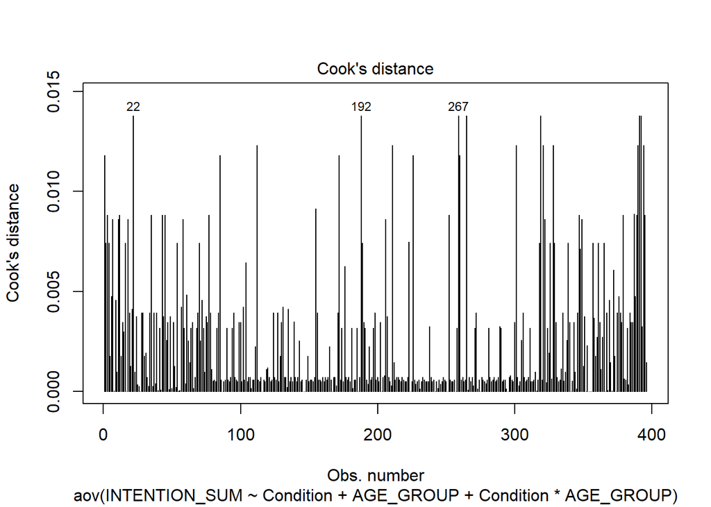

```r
#Cook Distanz test
plot(ANOVA_BENEFIT, 4)
```

```r
cd <- cooks.distance(ANOVA_BENEFIT)
view(cd<4/396)

indices_to_remove <- c(1, 22, 85, 113, 175, 192, 216, 231, 267, 268, 273, 309, 328, 330, 337, 399, 400, 401, 403)

MA_data_no_outliers <- MA_data_no_outliers[-indices_to_remove, ]

#ANOVA without outliers
ANOVA_BENEFIT_NO_OUTLIERS <- aov(INTENTION_SUM ~ Condition + AGE_GROUP + Condition*AGE_GROUP, p.adjust.method = "bonferroni", data = MA_data_no_outliers)
#Requirement 1: Metric scaling of the AV : Yes

#Requirement 2: Homogeneity of variances

leveneTest(INTENTION_SUM ~ Condition*AGE_GROUP, data = MA_data)
```

```
## Levene's Test for Homogeneity of Variance (center = median)
##        Df F value    Pr(>F)
## group   5  6.5959 6.569e-06 ***
##       390
## ---
## Signif. codes:  0 '***' 0.001 '**' 0.01 '*' 0.05 '.' 0.1 ' ' 1
```

```r
leveneTest(INTENTION_SUM ~ Condition*AGE_GROUP, data = MA_data_no_outliers)
```

```
## Levene's Test for Homogeneity of Variance (center = median)
##        Df F value    Pr(>F)
## group   5  7.8872 4.445e-07 ***
##       375
## ---
## Signif. codes:  0 '***' 0.001 '**' 0.01 '*' 0.05 '.' 0.1 ' ' 1
```

```r
#The variances are not equal, as p < 0.05. Violation of the homogeneity assumption.
```

##ANOVA Requierements 2

```r
nv <- lm(INTENTION_SUM ~ Condition*AGE_GROUP, data = MA_data)

nvno <- lm(INTENTION_SUM ~ Condition*AGE_GROUP, data = MA_data_no_outliers)

ANOVA_BENEFIT_ONE_WAY <- oneway.test(INTENTION_SUM ~ Condition + AGE_GROUP + Condition*AGE_GROUP, data = MA_data, var.equal = FALSE)
print(ANOVA_BENEFIT_ONE_WAY)
```

```
##
##  One-way analysis of means (not assuming equal variances)
##
## data:  INTENTION_SUM and Condition + AGE_GROUP + Condition * AGE_GROUP
## F = 6.9816, num df = 5.00, denom df = 178.25, p-value = 5.566e-06
```

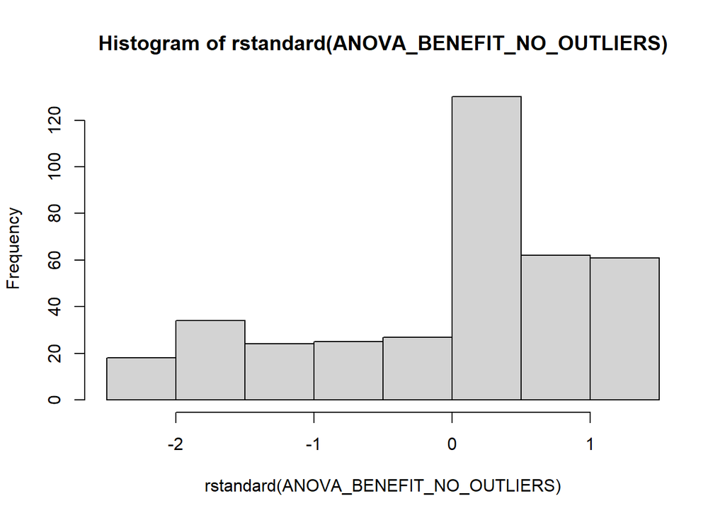

```r
hist(rstandard(ANOVA_BENEFIT_NO_OUTLIERS))
```

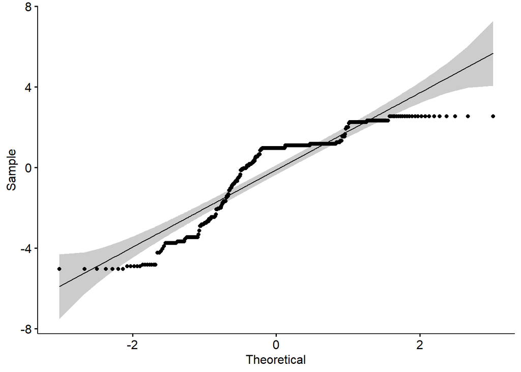

```r
ggqqplot(residuals(nv))
```

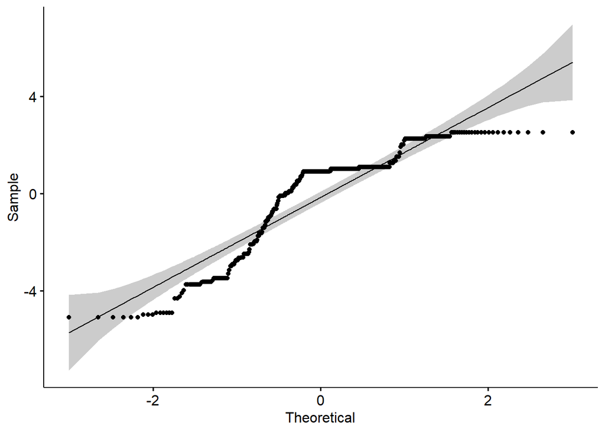

```r
ggqqplot(residuals(nvno))
```

```r
#plot(ANOVA_BENEFIT, 2)

#Requirement 3: Assumption of a normal distribution can only be partially accepted
```

#Prerequisite for a t-test with independent samples

```r
#H0 : normal distribution if p > 0.05
Young <- subset(MA_data, MA_data$AGE_GROUP == "18-29")
Old <- subset(MA_data, MA_data$AGE_GROUP == "30-75")

#AMOTIVATION
par(mfrow=c(1,2))
shapiro.test(Young$AMOTIVATION_SUM)
```

```
##
##  Shapiro-Wilk normality test
##
## data:  Young$AMOTIVATION_SUM
## W = 0.94611, p-value = 2.545e-06
```

```r
hist(scale(Young$AMOTIVATION_SUM))
shapiro.test(Old$AMOTIVATION_SUM)
```

```
##
##  Shapiro-Wilk normality test
##
## data:  Old$AMOTIVATION_SUM
## W = 0.87881, p-value = 3.92e-12
```

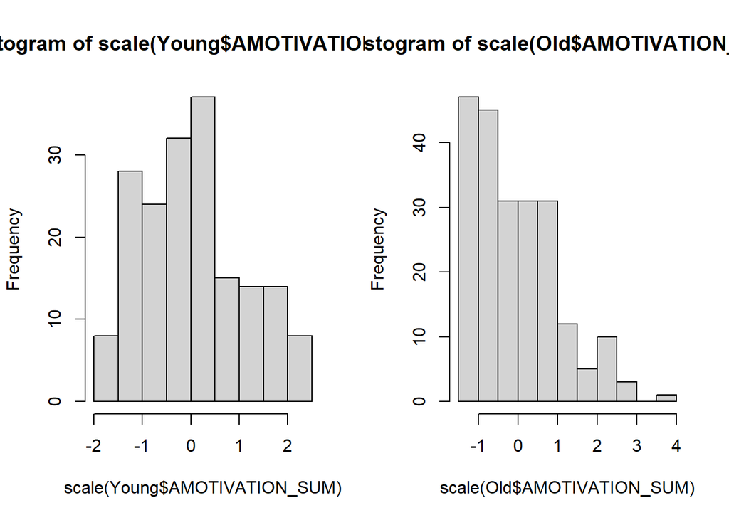

```r
hist(scale(Old$AMOTIVATION_SUM))
```

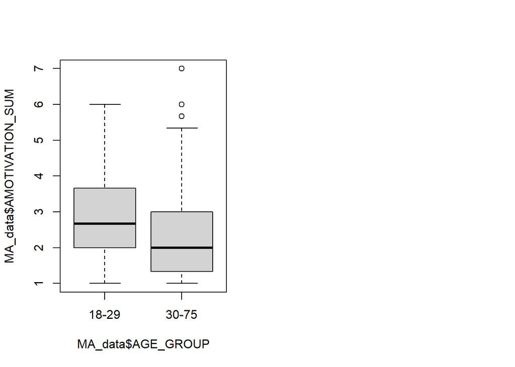

```r
boxplot(MA_data$AMOTIVATION_SUM ~ MA_data$AGE_GROUP)

#EXTERNAL_REGULATION
par(mfrow=c(1,2))
```

```r
shapiro.test(Young$EXTERNAL_REGULATION_SUM)
```

```
##
##  Shapiro-Wilk normality test
##
## data:  Young$EXTERNAL_REGULATION_SUM
## W = 0.88012, p-value = 8.256e-11
```

```r
hist(scale(Young$EXTERNAL_REGULATION_SUM))
shapiro.test(Old$EXTERNAL_REGULATION_SUM)
```

```
##
##  Shapiro-Wilk normality test
##
## data:  Old$EXTERNAL_REGULATION_SUM
## W = 0.78366, p-value < 2.2e-16
```

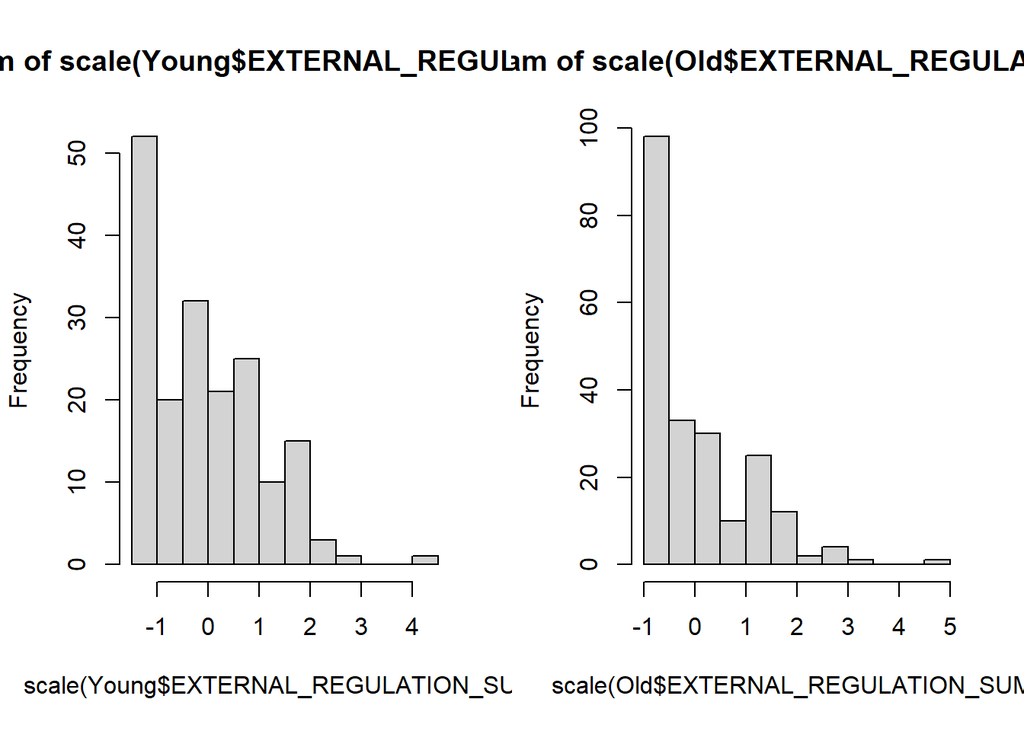

```r
hist(scale(Old$EXTERNAL_REGULATION_SUM))
```

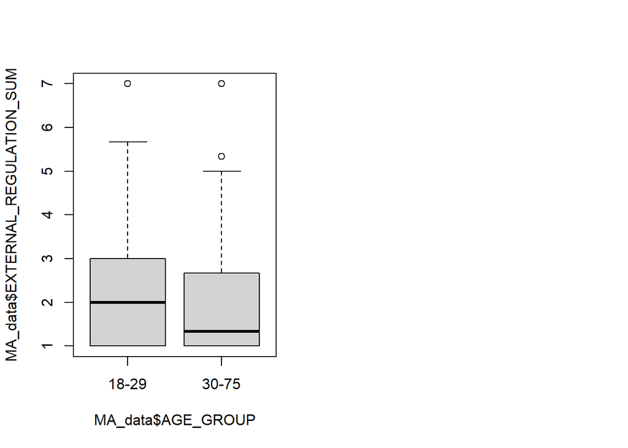

```r
boxplot(MA_data$EXTERNAL_REGULATION_SUM ~ MA_data$AGE_GROUP)

#INTROJECTED_REGULATION
par(mfrow=c(1,2))
```

```r
shapiro.test(Young$INTROJECTED_REGULATION_SUM)
```

```
##
##  Shapiro-Wilk normality test
##
## data:  Young$INTROJECTED_REGULATION_SUM
## W = 0.97423, p-value = 0.002036
```

```r
hist(scale(Young$INTROJECTED_REGULATION_SUM))
shapiro.test(Old$INTROJECTED_REGULATION_SUM)
```

```
##
##  Shapiro-Wilk normality test
##
## data:  Old$INTROJECTED_REGULATION_SUM
## W = 0.96681, p-value = 5.905e-05
```

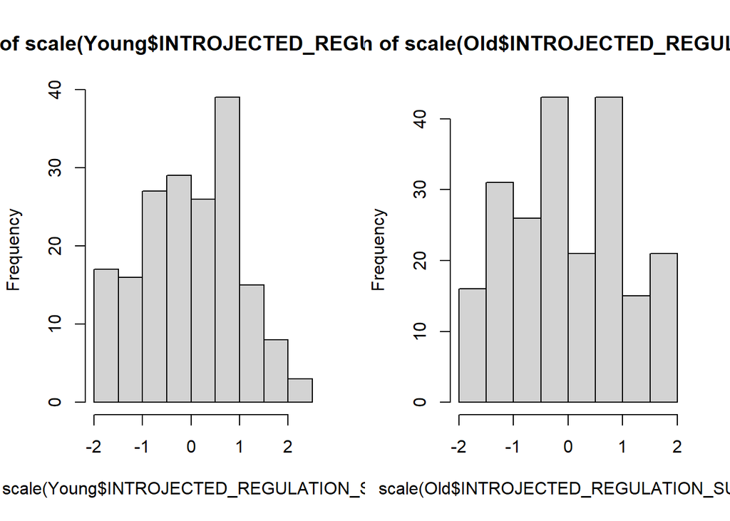

```r
hist(scale(Old$INTROJECTED_REGULATION_SUM))
```

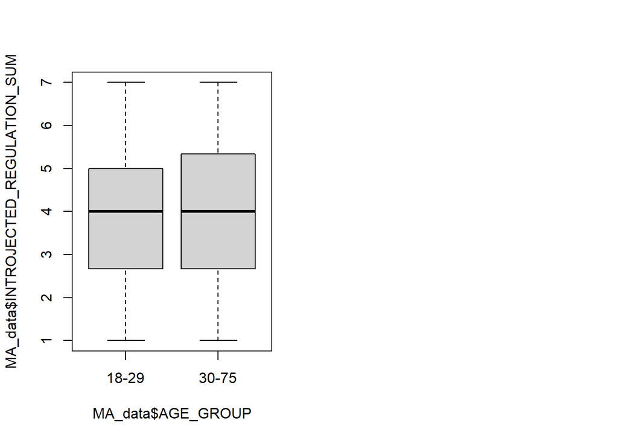

```r
boxplot(MA_data$INTROJECTED_REGULATION_SUM ~ MA_data$AGE_GROUP)

#IDENTIFIED_REGUALTION
par(mfrow=c(1,2))
```

```r
shapiro.test(Young$IDENTIFIED_REGUALTION_SUM)
```

```
##
##  Shapiro-Wilk normality test
##
## data:  Young$IDENTIFIED_REGUALTION_SUM
## W = 0.89214, p-value = 3.904e-10
```

```r
hist(scale(Young$IDENTIFIED_REGUALTION_SUM))
shapiro.test(Old$IDENTIFIED_REGUALTION_SUM)
```

```
##
##  Shapiro-Wilk normality test
##
## data:  Old$IDENTIFIED_REGUALTION_SUM
## W = 0.74314, p-value < 2.2e-16
```

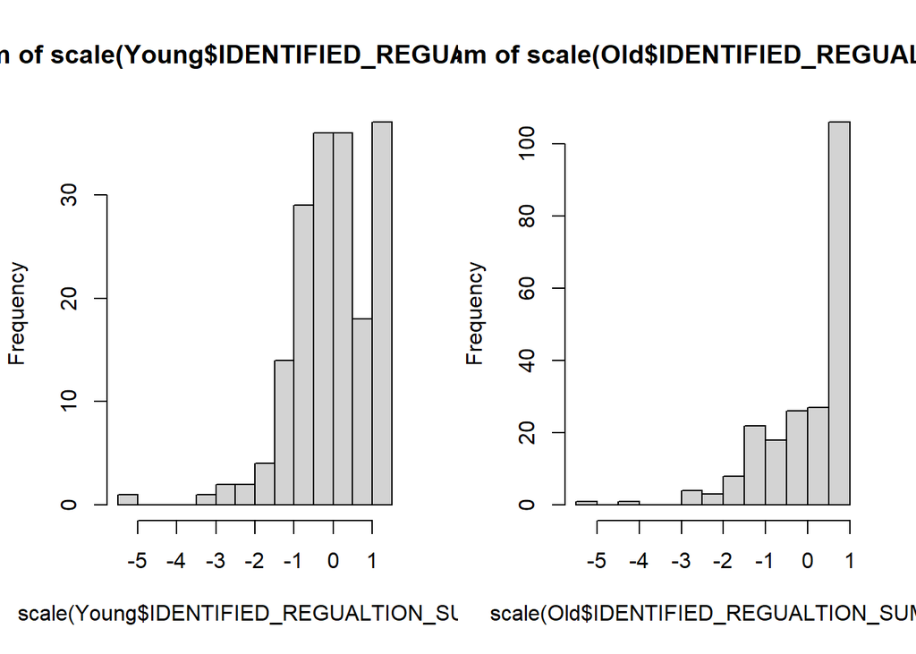

```r
hist(scale(Old$IDENTIFIED_REGUALTION_SUM))
```

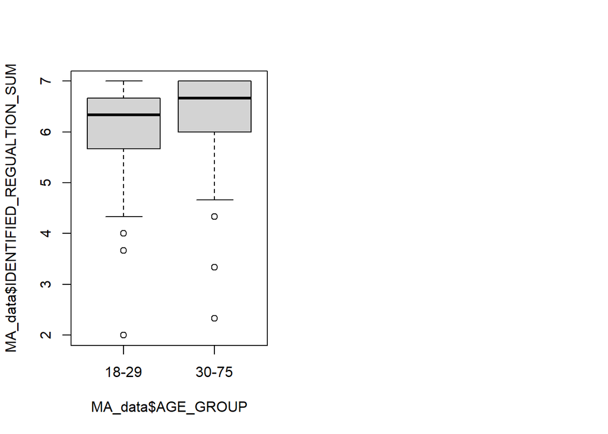

```r
boxplot(MA_data$IDENTIFIED_REGUALTION_SUM ~ MA_data$AGE_GROUP)

#INTEGRATED_REGULATION
par(mfrow=c(1,2))
```

```r
shapiro.test(Young$INTEGRATED_REGULATION_SUM)
```

```
##
##  Shapiro-Wilk normality test
##
## data:  Young$INTEGRATED_REGULATION_SUM
## W = 0.97899, p-value = 0.008077
```

```r
hist(scale(Young$INTEGRATED_REGULATION_SUM))
shapiro.test(Old$INTEGRATED_REGULATION_SUM)
```

```
##
##  Shapiro-Wilk normality test
##
## data:  Old$INTEGRATED_REGULATION_SUM
## W = 0.90496, p-value = 1.693e-10
```

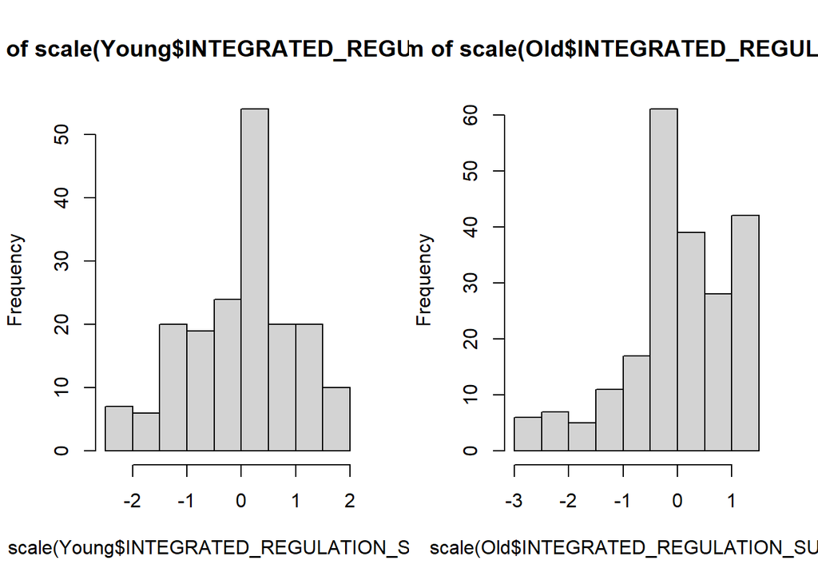

```r
hist(scale(Old$INTEGRATED_REGULATION_SUM))
```

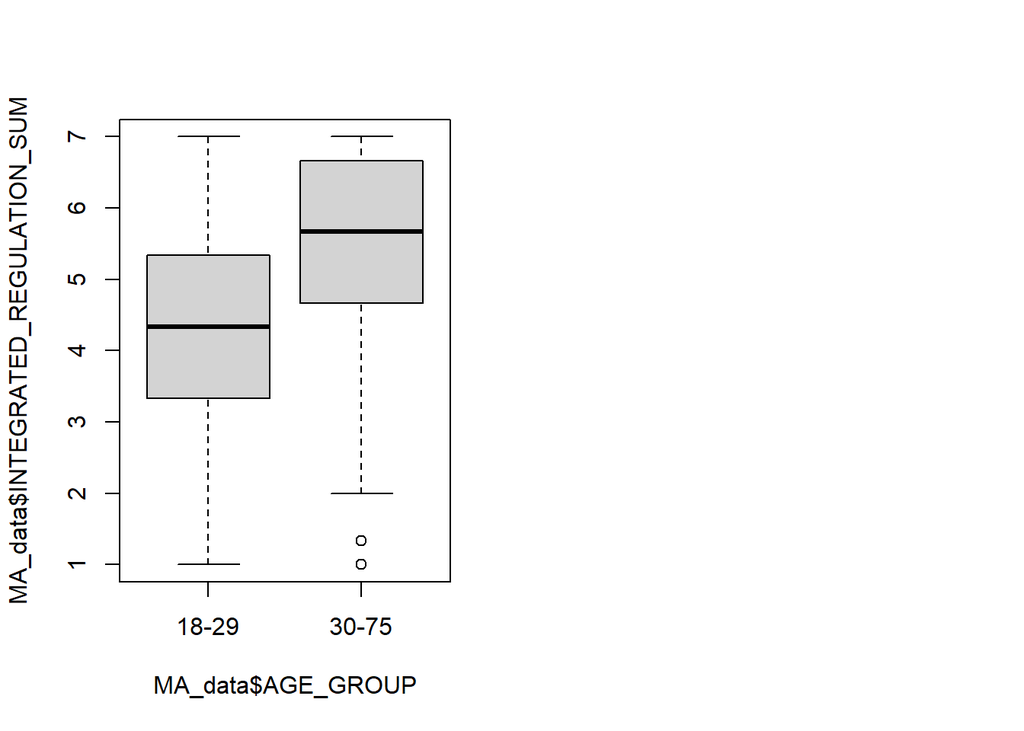

```r
boxplot(MA_data$INTEGRATED_REGULATION_SUM ~ MA_data$AGE_GROUP)

#INTRINSIC_REGUALTION
par(mfrow=c(1,2))
```

```r
shapiro.test(Young$INTRINSIC_REGULATION_SUM)
```

```
##
##  Shapiro-Wilk normality test
##
## data:  Young$INTRINSIC_REGULATION_SUM
## W = 0.97519, p-value = 0.002667
```

```r
hist(scale(Young$INTRINSIC_REGULATION_SUM))
shapiro.test(Old$INTRINSIC_REGULATION_SUM)
```

```
##
##  Shapiro-Wilk normality test
##
## data:  Old$INTRINSIC_REGULATION_SUM
## W = 0.92344, p-value = 3.722e-09
```

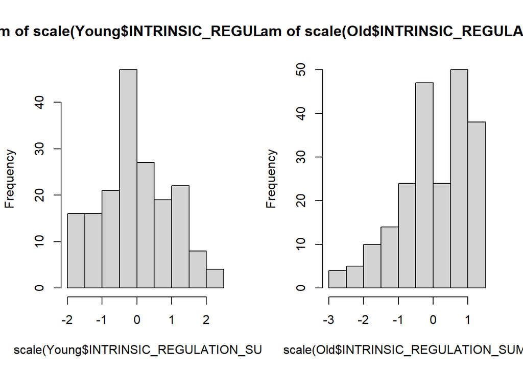

```r
hist(scale(Old$INTRINSIC_REGULATION_SUM))
```

```r
boxplot(MA_data$INTRINSIC_REGULATION_SUM ~ MA_data$AGE_GROUP)

#uniform distribution is not given according to the shapiro test, the histograms suggest a partial uniform distribution

#equality of variances
LeveneTest(MA_data$AMOTIVATION_SUM, MA_data$AGE_GROUP)
```

[output not shown]

```
## Levene's Test for Homogeneity of Variance (center = median)
##        Df F value Pr(>F)
## group   1  1.6213 0.2037
##       394
```

```r
LeveneTest(MA_data$EXTERNAL_REGULATION_SUM, MA_data$AGE_GROUP)
```

```
## Levene's Test for Homogeneity of Variance (center = median)
##        Df F value  Pr(>F)
## group   1  2.7956 0.09532 .
##       394
## ---
## Signif. codes:  0 '***' 0.001 '**' 0.01 '*' 0.05 '.' 0.1 ' ' 1
```

```r
LeveneTest(MA_data$INTROJECTED_REGULATION_SUM, MA_data$AGE_GROUP)
```

```
## Levene's Test for Homogeneity of Variance (center = median)
##        Df F value Pr(>F)
## group   1  1.8955 0.1694
##       394
```

```r
LeveneTest(MA_data$IDENTIFIED_REGUALTION_SUM, MA_data$AGE_GROUP)
```

```
## Levene's Test for Homogeneity of Variance (center = median)
##        Df F value Pr(>F)
## group   1  1.1763 0.2788
##       394
```

```r
LeveneTest(MA_data$INTEGRATED_REGULATION_SUM, MA_data$AGE_GROUP)
```

```
## Levene's Test for Homogeneity of Variance (center = median)
##        Df F value Pr(>F)
## group   1  0.3213 0.5712
##       394
```

```r
LeveneTest(MA_data$INTRINSIC_REGULATION_SUM, MA_data$AGE_GROUP)
```

```
## Levene's Test for Homogeneity of Variance (center = median)
##        Df F value Pr(>F)
## group   1  0.4514 0.5021
##       394
```

```r
#equal variance for all is given
```

[figure not shown]

#Preregistered analysis The following preregistered hypotheses were tested for significance within the code.

H1 Benefit Hypothesis(MainEffect):The willingness to donate blood increases significantly when an incentive is provided

H2 Age Hypothesis(MainEffect):The older the person,the higher the Blood donation intention

H3 Interaction Hypothesis(Interaction):In contrast to the social incentive, the individual incentive increases the willingness to donate blood significantly more in younger people than in older people

##ANOVA Experiment

```r
#Since there is no homogeneity of variance, the standard errors must be calculated "robustly". This function ensures that the ANOVA is less susceptible to unequal variances

summary(ANOVA_BENEFIT, robust = TRUE)
```

```
##                      Df Sum Sq Mean Sq F value   Pr(>F)
## Condition             2    0.2    0.12   0.026    0.974
## AGE_GROUP             1  163.6  163.60  35.751 5.07e-09 ***
## Condition:AGE_GROUP   2    4.1    2.03   0.444    0.641
## Residuals           390 1784.6    4.58
## ---
## Signif. codes:  0 '***' 0.001 '**' 0.01 '*' 0.05 '.' 0.1 ' ' 1
```

```r
Anova(ANOVA_BENEFIT, type=3)
```

```
## Anova Table (Type III tests)
##
## Response: INTENTION_SUM
##                      Sum Sq  Df  F value    Pr(>F)
## (Intercept)         1353.75   1 295.8354 < 2.2e-16 ***
## Condition              2.53   2   0.2767  0.758437
## AGE_GROUP             38.00   1   8.3041  0.004174 **
## Condition:AGE_GROUP    4.07   2   0.4445  0.641475
## Residuals           1784.65 390
## ---
## Signif. codes:  0 '***' 0.001 '**' 0.01 '*' 0.05 '.' 0.1 ' ' 1
```

```r
MA_data_no_outliers %>%
 group_by(Condition) %>%
 summarise(M = mean(INTENTION_SUM),
           SD = sd(INTENTION_SUM),
           N = n()) %>%
  as.data.frame()
```

```
##   Condition        M       SD   N
## 1         1 5.351852 2.188985 126
## 2         2 5.367188 2.115162 128
## 3         3 5.309711 2.335668 127
```

```r
MA_data_no_outliers %>%
 group_by(AGE_GROUP) %>%
 summarise(M = mean(INTENTION_SUM),
           SD = sd(INTENTION_SUM),
           N = n()) %>%
  as.data.frame()
```

```
##   AGE_GROUP        M       SD   N
## 1     18-29 4.608614 2.313963 178
## 2     30-75 5.986864 1.896915 203
```

```r
MA_data_no_outliers %>%
 group_by(Condition) %>%
 summarise(M = mean(INTENTION_SUM),
           SD = sd(INTENTION_SUM),
           N = n()) %>%
  as.data.frame()
```

```
##   Condition        M       SD   N
## 1         1 5.351852 2.188985 126
## 2         2 5.367188 2.115162 128
## 3         3 5.309711 2.335668 127
```

```r
#ANOVA with Cook Distance Test
Anova(ANOVA_BENEFIT_NO_OUTLIERS, type=3)
```

```
## Anova Table (Type III tests)
##
## Response: INTENTION_SUM
##                      Sum Sq  Df  F value    Pr(>F)
## (Intercept)         1319.34   1 296.0150 < 2.2e-16 ***
## Condition              2.06   2   0.2308  0.793987
## AGE_GROUP             43.07   1   9.6635  0.002023 **
## Condition:AGE_GROUP    3.17   2   0.3552  0.701254
## Residuals           1671.38 375
## ---
## Signif. codes:  0 '***' 0.001 '**' 0.01 '*' 0.05 '.' 0.1 ' ' 1
```

```r
#Post Hoc Test
TukeyHSD(ANOVA_BENEFIT, conf.level = .95)
```

```
##   Tukey multiple comparisons of means
##     95% family-wise confidence level
##
## Fit: aov(formula = INTENTION_SUM ~ Condition + AGE_GROUP + Condition * AGE_GROUP, data = MA_data, p.adjust.method = "bonferroni")
##
## $Condition
##            diff        lwr       upr     p adj
## 2-1  0.02708510 -0.5901467 0.6443169 0.9941411
## 3-1 -0.03331376 -0.6563638 0.5897363 0.9913139
## 3-2 -0.06039886 -0.6788343 0.5580366 0.9713169
##
## $AGE_GROUP
##                 diff       lwr      upr p adj
## 30-75-18-29 1.290367 0.8659168 1.714817     0
##
## $`Condition:AGE_GROUP`
##                        diff         lwr       upr     p adj
## 2:18-29-1:18-29 -0.07768362 -1.20094530 1.0455781 0.9999578
## 3:18-29-1:18-29 -0.28005464 -1.39399321 0.8338839 0.9794499
## 1:30-75-1:18-29  1.08098592  0.00665037 2.1553215 0.0475942
## 2:30-75-1:18-29  1.14912281  0.09109732 2.2071483 0.0243762
## 3:30-75-1:18-29  1.28864734  0.20720398 2.3700907 0.0092182
## 3:18-29-2:18-29 -0.20237103 -1.32105856 0.9163165 0.9954560
## 1:30-75-2:18-29  1.15866953  0.07941075 2.2379283 0.0271775
## 2:30-75-2:18-29  1.22680642  0.16378216 2.2898307 0.0131758
## 3:30-75-2:18-29  1.36633096  0.27999656 2.4526654 0.0047692
## 1:30-75-3:18-29  1.36104056  0.29148840 2.4305927 0.0040952
## 2:30-75-3:18-29  1.42917745  0.37600942 2.4823455 0.0016571
## 3:30-75-3:18-29  1.56870199  0.49201042 2.6453936 0.0005284
## 2:30-75-1:30-75  0.06813689 -0.94305084 1.0793246 0.9999629
## 3:30-75-1:30-75  0.20766143 -0.82800380 1.2433267 0.9926504
## 3:30-75-2:30-75  0.13952454 -0.87921171 1.1582608 0.9987957
```

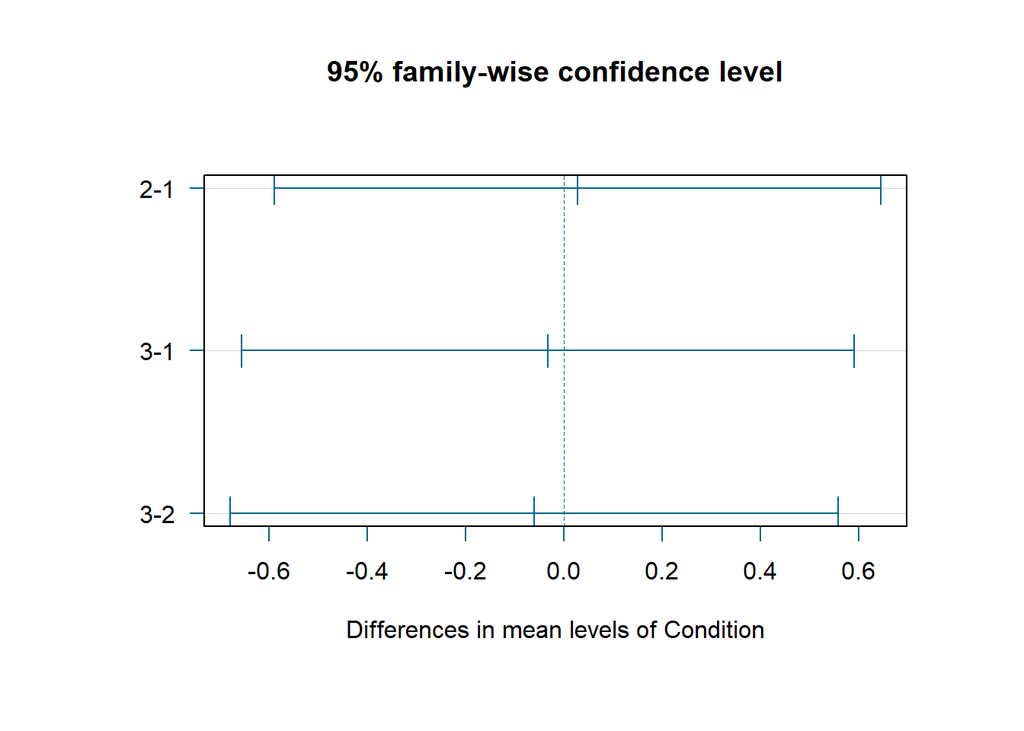

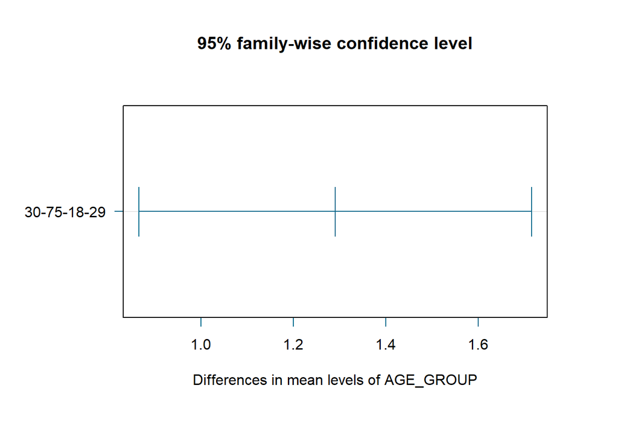

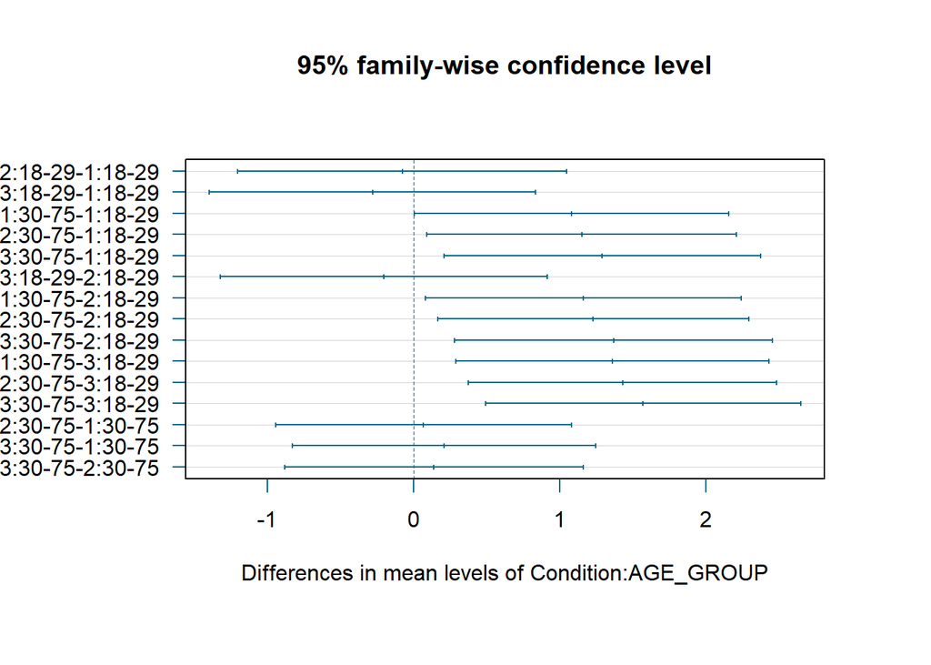

```r
TUKEY <- TukeyHSD(ANOVA_BENEFIT, conf.level = .95)

#Tuckey test representation :
par(mar = c(5, 5, 4, 2) + 2.0)
plot(TUKEY , las=1, col="#00688B")
```

```r
#No Outliers
TukeyHSD(ANOVA_BENEFIT_NO_OUTLIERS, conf.level = .95)
```

```
##   Tukey multiple comparisons of means
##     95% family-wise confidence level
##
## Fit: aov(formula = INTENTION_SUM ~ Condition + AGE_GROUP + Condition * AGE_GROUP, data = MA_data_no_outliers, p.adjust.method = "bonferroni")
##
## $Condition
##            diff        lwr       upr     p adj
## 2-1  0.01533565 -0.6080839 0.6387552 0.9981545
## 3-1 -0.04214057 -0.6667765 0.5824953 0.9862035
## 3-2 -0.05747621 -0.6796577 0.5647052 0.9742901
##
## $AGE_GROUP
##                 diff       lwr      upr p adj
## 30-75-18-29 1.377218 0.9509546 1.803481     0
##
## $`Condition:AGE_GROUP`
##                        diff         lwr       upr     p adj
## 2:18-29-1:18-29 -0.09662965 -1.21484600 1.0215867 0.9998730
## 3:18-29-1:18-29 -0.25886820 -1.36313143 0.8453950 0.9849550
## 1:30-75-1:18-29  1.17168395  0.09200465 2.2513633 0.0245757
## 2:30-75-1:18-29  1.24737692  0.17858603 2.3161678 0.0116673
## 3:30-75-1:18-29  1.35704503  0.27354246 2.4405476 0.0050423
## 3:18-29-2:18-29 -0.16223855 -1.27133031 0.9468532 0.9983440
## 1:30-75-2:18-29  1.26831360  0.18369632 2.3529309 0.0114188
## 2:30-75-2:18-29  1.34400657  0.27022764 2.4177855 0.0050836
## 3:30-75-2:18-29  1.45367468  0.36525148 2.5420979 0.0021018
## 1:30-75-3:18-29  1.43055216  0.36032596 2.5007784 0.0020768
## 2:30-75-3:18-29  1.50624512  0.44700451 2.5654857 0.0007981
## 3:30-75-3:18-29  1.61591323  0.54183012 2.6899963 0.0003004
## 2:30-75-1:30-75  0.07569296 -0.95789341 1.1092793 0.9999439
## 3:30-75-1:30-75  0.18536107 -0.86343092 1.2341531 0.9959228
## 3:30-75-2:30-75  0.10966811 -0.92791138 1.1472476 0.9996582
```

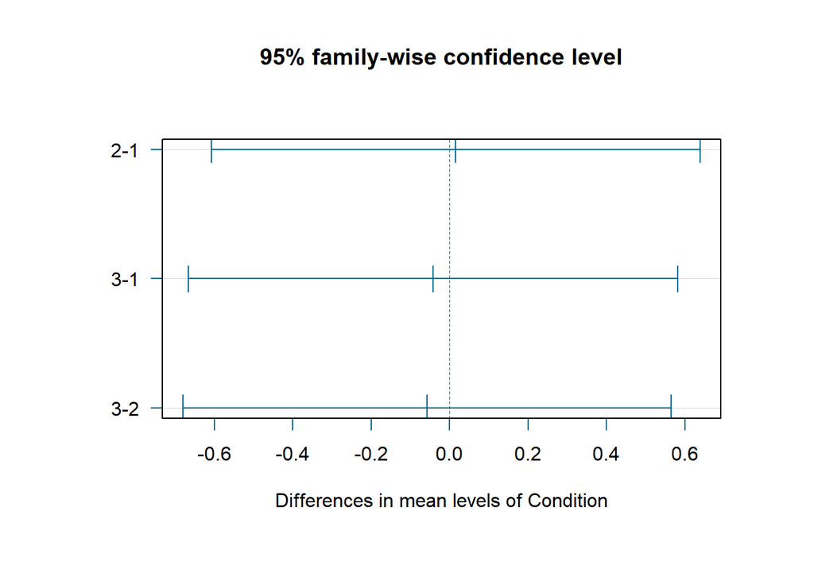

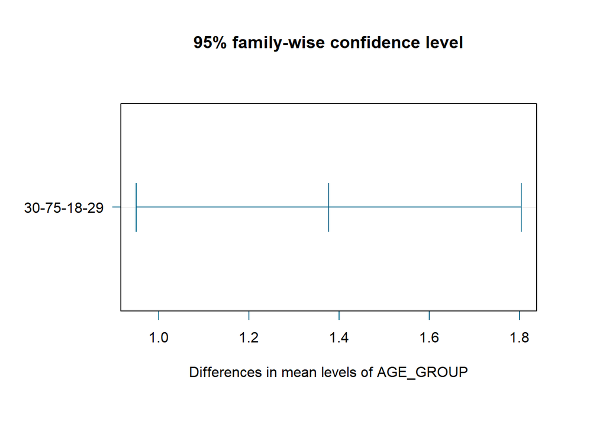

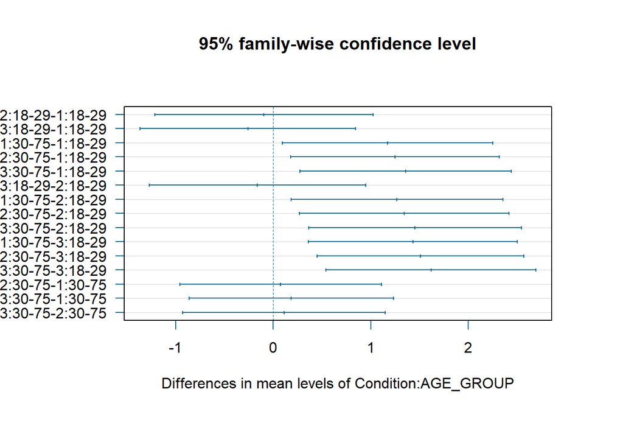

```r
TUKEY_no_outliers <- TukeyHSD(ANOVA_BENEFIT_NO_OUTLIERS, conf.level = .95)

par(mar = c(5, 5, 4, 2) + 2.0)
plot(TUKEY_no_outliers , las=1, col="#00688B")
```

```r
#Table ANOVA
apa.aov.table(ANOVA_BENEFIT, filename = "ANOVA_APA_2.doc")
```

```
##
##
## ANOVA results using INTENTION_SUM as the dependent variable
##
##
##              Predictor      SS  df      MS      F    p partial_eta2
##            (Intercept) 1353.75   1 1353.75 295.84 .000
##              Condition    2.53   2    1.26   0.28 .758          .00
##              AGE_GROUP   38.00   1   38.00   8.30 .004          .02
##  Condition x AGE_GROUP    4.07   2    2.04   0.44 .641          .00
##                  Error 1784.65 390    4.58
##  CI_90_partial_eta2
##
##          [.00, .01]
##          [.00, .05]
##          [.00, .01]
##
##
## Note: Values in square brackets indicate the bounds of the 90% confidence interval for partial eta-squared
```

```r
apa.aov.table(ANOVA_BENEFIT_NO_OUTLIERS, filename = "ANOVA_APA_3.doc")
```

```
##
##
## ANOVA results using INTENTION_SUM as the dependent variable
##
##
##              Predictor      SS  df      MS      F    p partial_eta2
##            (Intercept) 1319.34   1 1319.34 296.01 .000
##              Condition    2.06   2    1.03   0.23 .794          .00
##              AGE_GROUP   43.07   1   43.07   9.66 .002          .03
##  Condition x AGE_GROUP    3.17   2    1.58   0.36 .701          .00
##                  Error 1671.38 375    4.46
##  CI_90_partial_eta2
##
##          [.00, .01]
##          [.01, .06]
##          [.00, .01]
##
##
## Note: Values in square brackets indicate the bounds of the 90% confidence interval for partial eta-squared
```

```r
#correlations
cor.test(MA_data_no_outliers$ALTER,MA_data_no_outliers$INTENTION_SUM)
```

```
##
##  Pearson's product-moment correlation
##
## data:  MA_data_no_outliers$ALTER and MA_data_no_outliers$INTENTION_SUM
## t = 4.6512, df = 379, p-value = 4.566e-06
## alternative hypothesis: true correlation is not equal to 0
## 95 percent confidence interval:
##  0.1350596 0.3252519
## sample estimates:
##       cor
## 0.2323759
```

```r
cor.test(MA_data_no_outliers$AGE_GROUP_MEDIATION,MA_data_no_outliers$INTENTION_SUM)
```

```
##
##  Pearson's product-moment correlation
##
## data:  MA_data_no_outliers$AGE_GROUP_MEDIATION and MA_data_no_outliers$INTENTION_SUM
## t = 6.3854, df = 379, p-value = 5.005e-10
## alternative hypothesis: true correlation is not equal to 0
## 95 percent confidence interval:
##  0.2180174 0.3996170
## sample estimates:
##       cor
## 0.3116604
```

H1 must be discarded H2 can be assumed H3 must be discarded

#Graphic Processing ANOVA

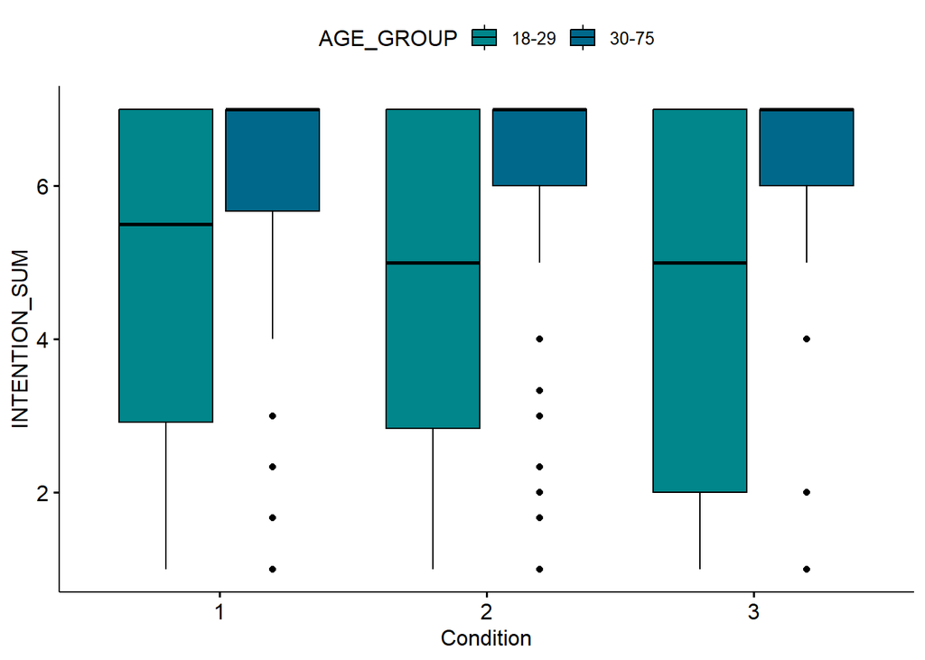

```r
Meine_Palette <- c("#00868B", "#00688B")
#Boxplot
ggboxplot(MA_data, x = "Condition", y = "INTENTION_SUM", fill = "AGE_GROUP", palette = Meine_Palette)
```

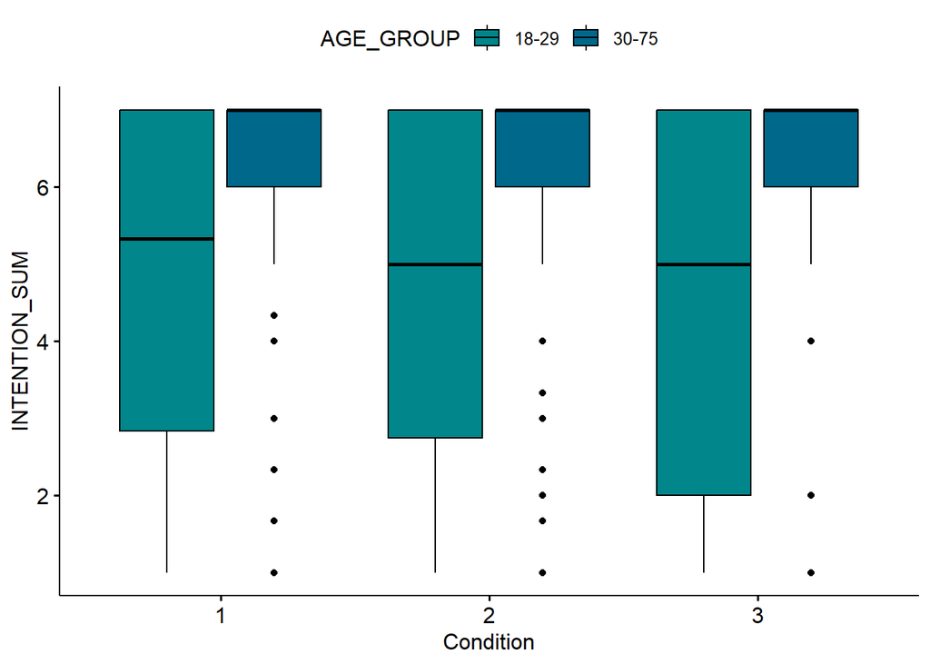

```r
#Boxblot with no outliers
ggboxplot(MA_data_no_outliers, x = "Condition", y = "INTENTION_SUM", fill = "AGE_GROUP", palette = Meine_Palette)
```

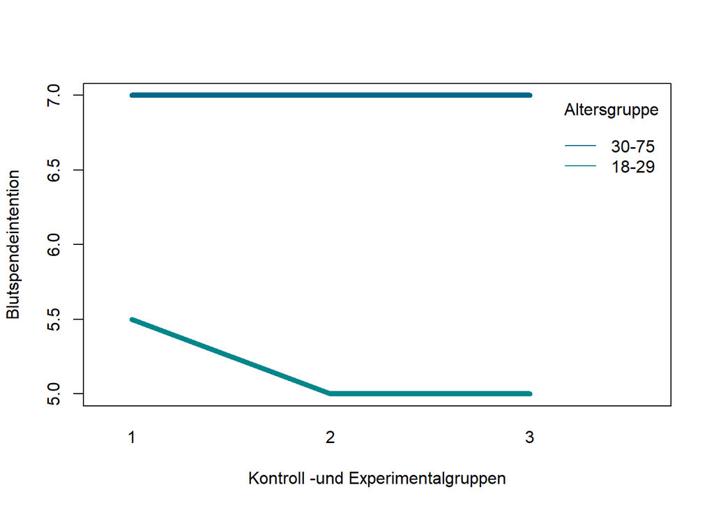

```r
#Interactionplot

interaction.plot(x.factor = MA_data$Condition, #x-axis variable
                 trace.factor = MA_data$AGE_GROUP, #variable for lines
                 response = MA_data$INTENTION_SUM, #y-axis variable
                 fun = median, #metric to plot
                 ylab = "Blutspendeintention",
                 xlab = "Kontroll -und Experimentalgruppen",
                 col = c("#00868B", "#00688B"),
                 lty = 1, #line type
                 lwd = 5, #line width
                 trace.label = "Altersgruppe")
```

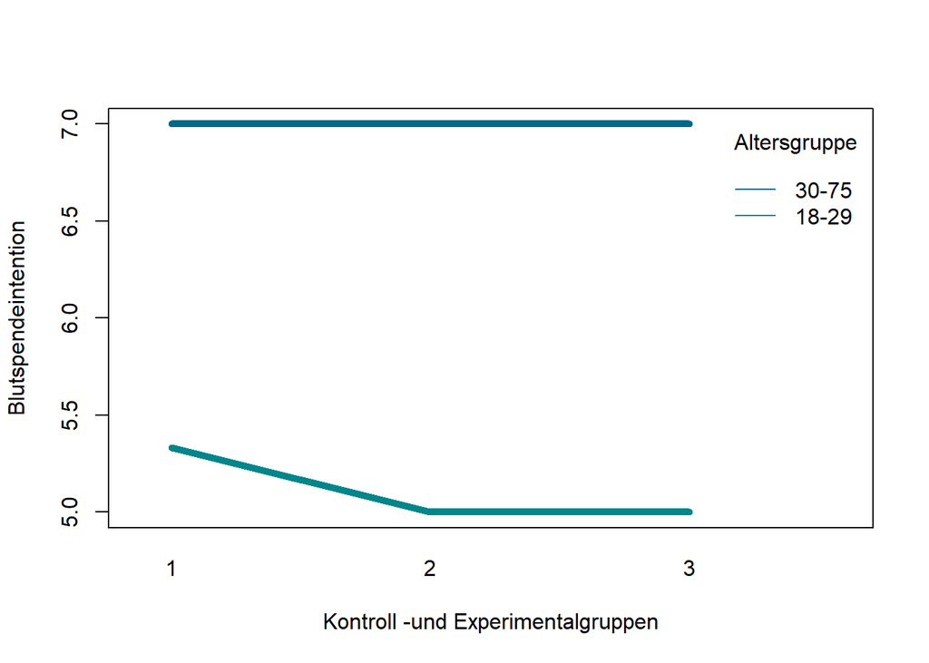

```r
#No outliers

interaction.plot(x.factor = MA_data_no_outliers$Condition, #x-axis variable
                 trace.factor = MA_data_no_outliers$AGE_GROUP, #variable for lines
                 response = MA_data_no_outliers$INTENTION_SUM, #y-axis variable
                 fun = median, #metric to plot
                 ylab = "Blutspendeintention",
                 xlab = "Kontroll -und Experimentalgruppen",
                 col = c("#00868B", "#00688B"),
                 lty = 1, #line type
                 lwd = 5, #line width
                 trace.label = "Altersgruppe")
```

##Additional t tests for the interaction effect

```r
Young$Exp_Group_Young <- ifelse(Young$Condition %in%
                                  c(1, 2), Young$Condition, NA)

wilcox_test(INTENTION_SUM ~ Exp_Group_Young, data = Young, alternative = "greater", p.adjust.method = "bonferroni")
```

```
## # A tibble: 1 × 9
##   .y.           group1 group2    n1    n2 statistic     p p.adj p.adj.signif
## * <chr>         <chr>  <chr>  <int> <int>     <dbl> <dbl> <dbl> <chr>
## 1 INTENTION_SUM 1      2         60    59      1812 0.411 0.411 ns
```

#Preregistered analysis Self-Determination Theory

H4 Amotivation Hypothesis: Amotivation is significantly higher in the younger age category than in the older one

H5 Extrinsic Hypothesis: The younger the participants, the more extrinsic the motivation factor of the self-determination theory

```r
MA_data %>%
  group_by(AGE_GROUP) %>%
  summarise(
    M_AMOTIVATION = mean(AMOTIVATION_SUM, na.rm = TRUE),
    SD_AMOTIVATION = sd(AMOTIVATION_SUM, na.rm = TRUE),
    M_EXTERNAL = mean(EXTERNAL_REGULATION_SUM, na.rm = TRUE),
    SD_EXTERNAL = sd(EXTERNAL_REGULATION_SUM, na.rm = TRUE),
    M_INTROJECTED = mean(INTROJECTED_REGULATION_SUM, na.rm = TRUE),
    SD_INTROJECTED = sd(INTROJECTED_REGULATION_SUM, na.rm = TRUE),
    M_IDENTIFIED = mean(IDENTIFIED_REGUALTION_SUM, na.rm = TRUE),
    SD_IDENTIFIED = sd(IDENTIFIED_REGUALTION_SUM, na.rm = TRUE),
    M_INTEGRATED = mean(INTEGRATED_REGULATION_SUM, na.rm = TRUE),
    SD_INTEGRATED = sd(INTEGRATED_REGULATION_SUM, na.rm = TRUE),
    M_INTRINSIC = mean(INTRINSIC_REGULATION_SUM, na.rm = TRUE),
    SD_INTRINSIC = sd(INTRINSIC_REGULATION_SUM, na.rm = TRUE)
  ) %>%
  as.data.frame()
```

```
##   AGE_GROUP M_AMOTIVATION SD_AMOTIVATION M_EXTERNAL SD_EXTERNAL M_INTROJECTED
## 1     18-29      2.962963       1.295501   2.192593    1.178620      3.835185
## 2     30-75      2.291667       1.246312   1.851852    1.104684      4.049383
##   SD_INTROJECTED M_IDENTIFIED SD_IDENTIFIED M_INTEGRATED SD_INTEGRATED
## 1       1.554512     6.070370     0.7949163     4.316667      1.448591
## 2       1.696822     6.453704     0.7661553     5.336420      1.452785
##   M_INTRINSIC SD_INTRINSIC
## 1    3.683333     1.552026
## 2    5.206790     1.488782
```

```r
describeBy(MA_data$AMOTIVATION_SUM, MA_data$AGE_GROUP)
```

```
##
##  Descriptive statistics by group
## group: 18-29
##    vars   n mean  sd median trimmed  mad min max range skew kurtosis  se
## X1    1 180 2.96 1.3   2.67    2.88 0.99   1   6     5 0.56    -0.57 0.1
## ------------------------------------------------------------
## group: 30-75
##    vars   n mean   sd median trimmed  mad min max range skew kurtosis   se
## X1    1 216 2.29 1.25      2    2.11 1.48   1   7     6 1.14      0.9 0.08
```

```r
describeBy(MA_data$EXTERNAL_REGULATION_SUM, MA_data$AGE_GROUP)
```

```
##
##  Descriptive statistics by group
## group: 18-29
##    vars   n mean   sd median trimmed  mad min max range skew kurtosis   se
## X1    1 180 2.19 1.18      2    2.06 1.48   1   7     6 0.88     0.43 0.09
## ------------------------------------------------------------
## group: 30-75
##    vars   n mean  sd median trimmed  mad min max range skew kurtosis   se
## X1    1 216 1.85 1.1   1.33    1.66 0.49   1   7     6  1.4     1.89 0.08
```

```r
describeBy(MA_data$INTROJECTED_REGULATION_SUM, MA_data$AGE_GROUP)
```

```
##
##  Descriptive statistics by group
## group: 18-29
##    vars   n mean   sd median trimmed  mad min max range  skew kurtosis   se
## X1    1 180 3.84 1.55      4    3.85 1.48   1   7     6 -0.08    -0.81 0.12
## ------------------------------------------------------------
## group: 30-75
##    vars   n mean  sd median trimmed  mad min max range  skew kurtosis   se
## X1    1 216 4.05 1.7      4    4.05 1.98   1   7     6 -0.01    -0.94 0.12
```

```r
describeBy(MA_data$IDENTIFIED_REGUALTION_SUM, MA_data$AGE_GROUP)
```

```
##
##  Descriptive statistics by group
## group: 18-29
##    vars   n mean   sd median trimmed  mad min max range  skew kurtosis   se
## X1    1 180 6.07 0.79   6.33    6.15 0.74   2   7     5 -1.23     3.01 0.06
## ------------------------------------------------------------
## group: 30-75
##    vars   n mean   sd median trimmed  mad  min max range  skew kurtosis   se
## X1    1 216 6.45 0.77   6.67     6.6 0.49 2.33   7  4.67 -1.87     4.49 0.05
```

```r
describeBy(MA_data$INTEGRATED_REGULATION_SUM, MA_data$AGE_GROUP)
```

```
##
##  Descriptive statistics by group
## group: 18-29
##    vars   n mean   sd median trimmed  mad min max range  skew kurtosis   se
## X1    1 180 4.32 1.45   4.33    4.35 1.48   1   7     6 -0.22    -0.57 0.11
## ------------------------------------------------------------
## group: 30-75
##    vars   n mean   sd median trimmed  mad min max range  skew kurtosis  se
## X1    1 216 5.34 1.45   5.67    5.52 1.48   1   7     6 -0.97     0.65 0.1
```

```r
describeBy(MA_data$INTRINSIC_REGULATION_SUM, MA_data$AGE_GROUP)
```

```
##
##  Descriptive statistics by group
## group: 18-29
##    vars   n mean   sd median trimmed  mad min max range skew kurtosis   se
## X1    1 180 3.68 1.55   3.67    3.66 1.48   1   7     6 0.13    -0.69 0.12
## ------------------------------------------------------------
## group: 30-75
##    vars   n mean   sd median trimmed  mad min max range  skew kurtosis  se
## X1    1 216 5.21 1.49   5.33    5.36 1.48   1   7     6 -0.72    -0.12 0.1
```

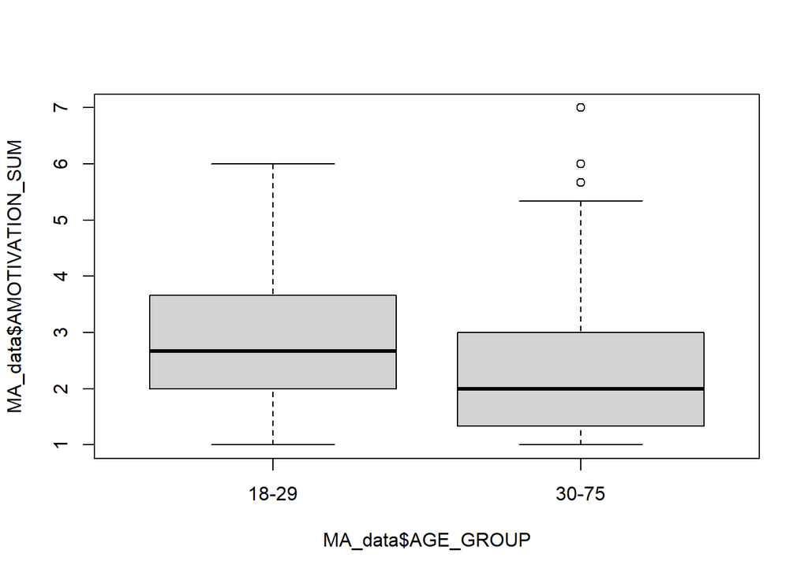

```r
boxplot(MA_data$AMOTIVATION_SUM ~ MA_data$AGE_GROUP)
```

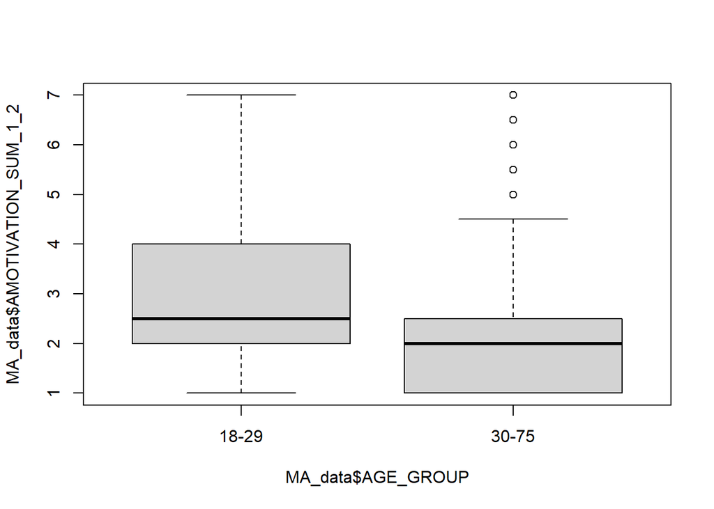

```r
boxplot(MA_data$AMOTIVATION_SUM_1_2 ~ MA_data$AGE_GROUP)
```

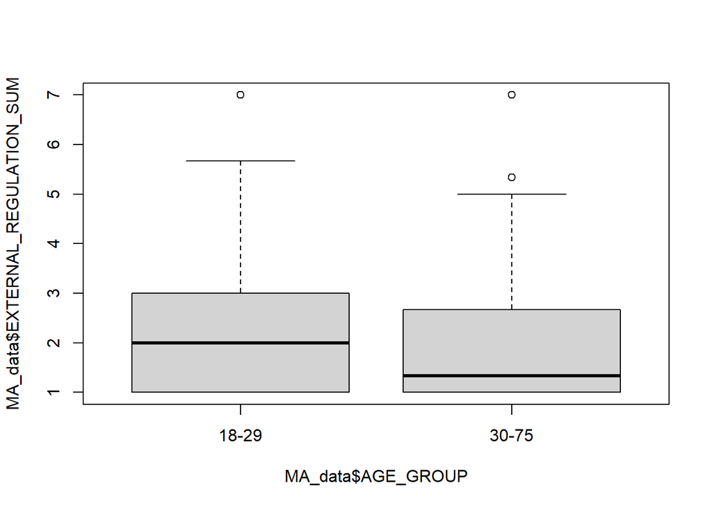

```r
boxplot(MA_data$EXTERNAL_REGULATION_SUM ~ MA_data$AGE_GROUP)
```

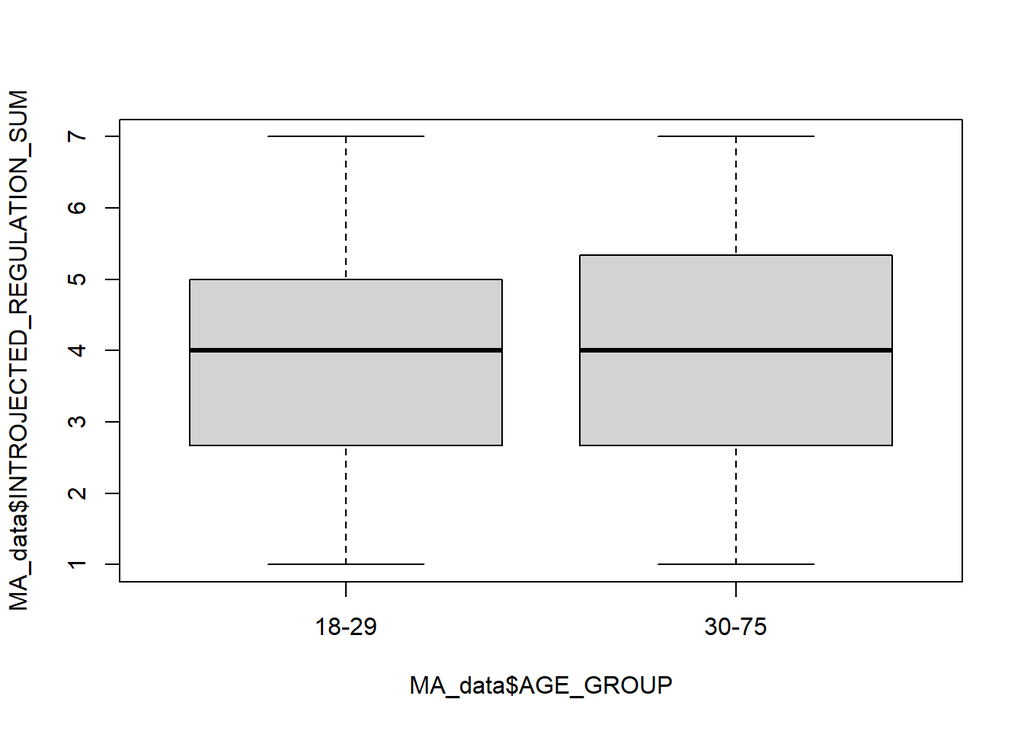

```r
boxplot(MA_data$INTROJECTED_REGULATION_SUM ~ MA_data$AGE_GROUP)
```

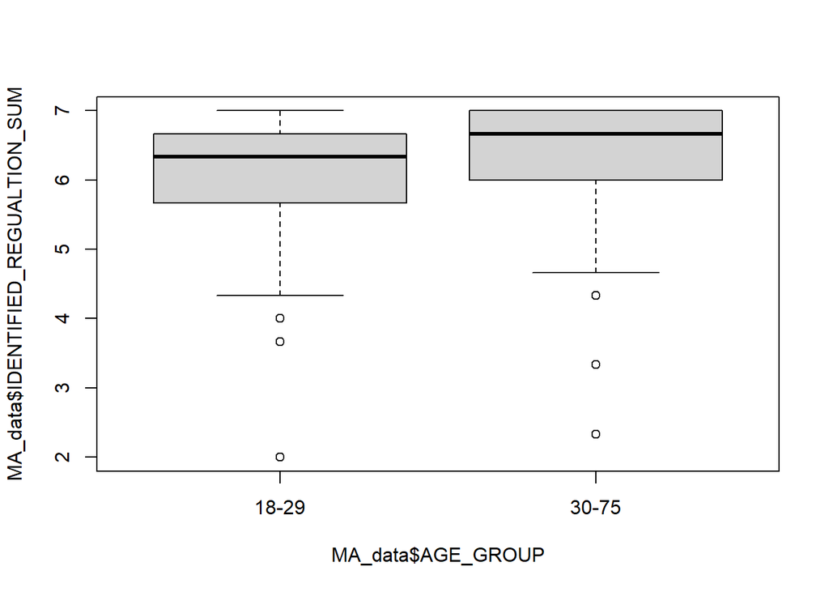

```r
boxplot(MA_data$IDENTIFIED_REGUALTION_SUM ~ MA_data$AGE_GROUP)
```

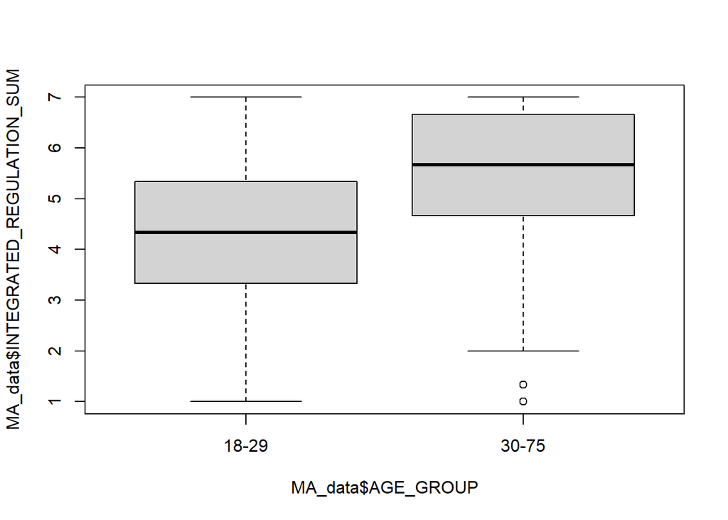

```r
boxplot(MA_data$INTEGRATED_REGULATION_SUM ~ MA_data$AGE_GROUP)
```